# The Steam Snoopers Present: Analyzing Gaming Industry Trends in the Steam Games Store

```python
#Imports used in this Project
import pandas as pd
import numpy as np
from google.colab import files
import datetime
import matplotlib.pyplot as plt
import seaborn as sns
import ast
from sklearn.ensemble import RandomForestRegressor, HistGradientBoostingRegressor
from sklearn.metrics import mean_squared_error, r2_score
from scipy import stats
from statsmodels.stats.multicomp import pairwise_tukeyhsd
from sklearn.model_selection import train_test_split
from sklearn.preprocessing import MultiLabelBinarizer, StandardScaler
from sklearn.cluster import KMeans
from yellowbrick.cluster import KElbowVisualizer
```

Team Members:

Austin Luu, Margaret Kato, Somy Park, Ian Henry, Emily Li, Ayomiposi Ajayi

Contributions:

Ian:

- A: Project idea – found the Kaggle dataset, provided some starting questions to ask.
- C: Data Exploration and Summary Statistics – completed hypothesis test question
- D: ML Algorithm Design/Development – wrote tree regression code.
- E: ML Algorithm Training and Test Data Analysis – wrote tree regression training code.
- F: Visualization, Result Analysis, Conclusion – wrote code for prediction vs actual CCU visualization.
- G: Final Tutorial Report Creation – set up the final file and hosted final project page.

Austin:

- B: Dataset Curation and Preprocessing – set up the Checkpoint 2 Google Colab and did some preprocessing (such as cutting unnecessary rows and putting data into a Pandas dataframe).
- C: Data Exploration and Summary Statistics – performed initial dataframe feature exploration (such as showing column names, dataframe shape, etc) and investigated feature correlation with a Pearson correlation matrix heatmap.
- G: Final Tutorial Report Creation – wrote the introduction to the project.

Emily:

- B: Dataset Curation and Preprocessing – completed majority of data cleaning, set up Steam_Cleaning Colab.
- D: ML Algorithm Design/Development – Random Forest Regression and tuning.
- F: Visualization, Result Analysis, Conclusion – visualization for Random Forest Regression, results analysis for Random Forest.
- G: Final Tutorial Report Creation – wrote introduction to the project.

Ayo:

- C: Data Exploration and Summary Statistics – "Most Popular Genre" section and generated graphs that show relationships between game genre and other factors. This includes the most popular genre of games released every year, the top 10 genre combinations that received the most peak concurrent players, and genre growth in games over time by number of games played.
- D: ML Algorithm Design/Development – Tried K-means clustering based on genres associated with each game, grouping together games with similar genre combinations.
- E: ML Algorithm Training and Test Data Analysis – wrote analysis for K-means clustering.

Somy:

- C: Data Exploration and Summary Statistics – worked on modeling the distribution of games released per year and found the year with the most games released. Cleaned up the graph for popular genre analysis.
- F: Visualization, Result Analysis, Conclusion – wrote the conclusion.
- G: Final Tutorial Report Creation – wrote results analysis and conclusion.

Margaret:

- C: Data Exploration and Summary Statistics – worked on the genre distribution visualization for the most popular year, 2023, and hypothesis test for average peak CCU between years.
- E: ML Algorithm Training and Test Data Analysis – wrote introduction and model intro/conclusion text for the Primary analysis and visualization section. Explained why we chose the models we did and some of the conclusions drawn.
- F: Visualization, Result Analysis, Conclusion – wrote the conclusion.
- G: Final Tutorial Report Creation – ported over checkpoint 2 code to the final report.

# Introduction (Why Are We Doing This?)

The gaming industry is a massive business with much promise for growth thanks to its high viewability and growing cultural impact [1]. There were an estimated 2.7 billion gamers in the world in 2020, and the industry is projected to grow, with average growth of the industry from 2015-2020 is 14.7% [2]. According to the Dentsu 2024 State of Gaming Report, the value of the gaming industry is greater than the combined values of both the film and music industries [3]. We’re interested in exploring trends within the gaming industry and we chose to look at a collection of games offered by the digital storefront, Steam, because of its extensive data collection and standardization in terms of game purchase and downloading as a leader in the online game marketplace industry. Steam is an industry leader in online gaming marketplaces. It holds 75% of US online gaming market share, and reached a record $10.8 billion in 2024 (increased 24.14% from 2023) [4]. This data set by Marton Bustos, recent as of August 2024, contains details such as pricing, sales data, release dates, and more, sourced from Steam’s API and Steam Spy.

Using this information, preliminary trends we’re interested in looking at include game genre popularity, player demographics, and historical trends within the digital game industry. What game features (specifically genres and tags) are the most popular? What features correlate most strongly with measures of positive player reception, such as positive ratings and higher peak concurrent player count (known as “peak CCU”)? We employed multiple machine learning approaches to understanding what makes a “positively received” game. Using all available features of games, could peak CCU and positive-to-negative rating ratio be predicted using regression? What was the most powerful predictor of these measures of positive reception? What were the most common game genres present in different clusters of games?

Although the market tends to be dominated by well-established titles, and can be volatile due to the impact of player interest and trends, we aim to investigate whether industry trends can be illuminated through data. This can provide potential insight that could give an edge in optimizing game development by highlighting the historically most high-yield genres and tags. Additionally, this analysis could highlight genres and tags that can be added to burgeoning game concepts, which could help elevate a novel idea, assisting smaller companies or independent developers find a better chance at success–ultimately enabling innovation in the online gaming space.

Sources:

[1] https://www.investopedia.com/articles/investing/053115/how-video-game-industry-changing.asp

[2] https://financesonline.com/video-games-industry-statistics/

[3] https://www.dentsu.com/reports/n2024_state_of_gaming_report_dl

[4] https://www.demandsage.com/steam-statistics/

# Data Curation

Dataset source: https://www.kaggle.com/datasets/fronkongames/steam-games-dataset/data?select=games.csv by Martin Bustos

```python
from google.colab import drive
drive.mount('/content/drive')
```

```python
df = pd.read_json("/content/drive/MyDrive/CMSC320 Group Project/games.json")
display(df)
```

|  | 20200 | 655370 | 1732930 | 1355720 | 1139950 | 1469160 | 1659180 | 1968760 | 1178150 | 320150 | ... | 3148680 | 2435240 | 2214970 | 3165130 | 3199580 | 3080940 | 2593970 | 3137150 | 3124670 | 3054200 |
| --- | --- | --- | --- | --- | --- | --- | --- | --- | --- | --- | --- | --- | --- | --- | --- | --- | --- | --- | --- | --- | --- |
| name | Galactic Bowling | Train Bandit | Jolt Project | Henosis™ | Two Weeks in Painland | Wartune Reborn | TD Worlds | Legend of Rome - The Wrath of Mars | MazM: Jekyll and Hyde | Deadlings: Rotten Edition | ... | Guard | Sulphur Memories: Alchemist | Get To The Gate | SLIME ORDER | Carbon Playtest | Femdom Game World: Mom | Blocky Farm | Infiltrate & Extract | Escape The Garage | Lober Lobe |
| release_date | Oct 21, 2008 | Oct 12, 2017 | Nov 17, 2021 | Jul 23, 2020 | Feb 3, 2020 | Feb 26, 2021 | Jan 9, 2022 | May 5, 2022 | Apr 2, 2020 | Nov 11, 2014 | ... | Aug 23, 2024 | Aug 9, 2024 | Aug 19, 2024 | Aug 28, 2024 | Sep 1, 2024 | Aug 22, 2024 | Aug 30, 2024 | Aug 30, 2024 | Aug 29, 2024 | Aug 30, 2024 |
| required_age | 0 | 0 | 0 | 0 | 0 | 0 | 0 | 0 | 0 | 0 | ... | 0 | 0 | 0 | 0 | 0 | 0 | 0 | 0 | 0 | 0 |
| price | 19.99 | 0.99 | 4.99 | 5.99 | 0.0 | 0.0 | 10.99 | 9.99 | 14.99 | 3.99 | ... | 0.59 | 11.99 | 19.99 | 0.99 | 0.0 | 4.19 | 8.99 | 0.0 | 4.99 | 4.49 |
| dlc_count | 0 | 0 | 0 | 0 | 0 | 0 | 1 | 0 | 0 | 0 | ... | 0 | 0 | 0 | 0 | 0 | 0 | 0 | 0 | 0 | 0 |
| detailed_description | Galactic Bowling is an exaggerated and stylize... | THE LAW!! Looks to be a showdown atop a train.... | Jolt Project: The army now has a new robotics ... | HENOSIS™ is a mysterious 2D Platform Puzzler w... | ABOUT THE GAME Play as a hacker who has arrang... | Feel tired of auto-fight? Feel tired of boring... | TD Worlds is a dynamic, highly strategical gam... | When the Roman people honored a simple warrior... | 'MazM: Jekyll and Hyde' is a darkly entertaini... | Death is lonely. He has zero friends on his Fa... | ... | This game is a classic adventure game where yo... | An alchemist. A former apothecary, now chased ... | Are you afraid of monsters? Western fantasy wo... | Guide the colorful slime to the goal. All you ... |  | . Femdom Game World - is a fascinating series ... | JOIN OUR DISCORD SERVER About the Game Enter t... | Mission brief: You are deployed to a heavily g... | Welcome to Escape The Garage, the thrilling es... | Scan Brain Lobes Organize &amp; clear dangerou... |
| about_the_game | Galactic Bowling is an exaggerated and stylize... | THE LAW!! Looks to be a showdown atop a train.... | Jolt Project: The army now has a new robotics ... | HENOSIS™ is a mysterious 2D Platform Puzzler w... | ABOUT THE GAME Play as a hacker who has arrang... | Feel tired of auto-fight? Feel tired of boring... | TD Worlds is a dynamic, highly strategical gam... | When the Roman people honored a simple warrior... | 'MazM: Jekyll and Hyde' is a darkly entertaini... | Death is lonely. He has zero friends on his Fa... | ... | This game is a classic adventure game where yo... | An alchemist. A former apothecary, now chased ... | Are you afraid of monsters? Western fantasy wo... | Guide the colorful slime to the goal. All you ... |  | . Femdom Game World - is a fascinating series ... | Enter the charming world of Blocky Farm where ... | Mission brief: You are deployed to a heavily g... | Welcome to Escape The Garage, the thrilling es... | Scan Brain Lobes Organize &amp; clear dangerou... |
| short_description | Galactic Bowling is an exaggerated and stylize... | THE LAW!! Looks to be a showdown atop a train.... | Shoot vehicles, blow enemies with a special at... | HENOSIS™ is a mysterious 2D Platform Puzzler w... | Two Weeks in Painland is a story-driven game a... | 'Wartune Reborn' epic magic TBS game was devel... | TD Worlds is a dynamic, highly strategical gam... | Experience a challenging match 3 game and help... | Players will experience the world through the ... | Arcade side-scroller with strategy elements! F... | ... | This game is a classic adventure game where yo... | Sulphur Memories: Alchemist is a traditional r... | GetToTheGate is a RPG about a girl that needs ... | Players just decide the order of the slimes! A... |  | Femdom Game World: Mom is a visual novel with ... | Create the farm of your dreams and grow big! M... | A top-down 3D stealth game where remaining und... | Wake up at an abandoned train station and find... | Brain centric, procedurally generated bullet h... |
| reviews |  |  |  |  |  |  |  |  |  |  | ... |  |  |  |  |  |  |  |  |  |  |
| header_image | https://cdn.akamai.steamstatic.com/steam/apps/... | https://cdn.akamai.steamstatic.com/steam/apps/... | https://cdn.akamai.steamstatic.com/steam/apps/... | https://cdn.akamai.steamstatic.com/steam/apps/... | https://cdn.akamai.steamstatic.com/steam/apps/... | https://cdn.akamai.steamstatic.com/steam/apps/... | https://cdn.akamai.steamstatic.com/steam/apps/... | https://cdn.akamai.steamstatic.com/steam/apps/... | https://cdn.akamai.steamstatic.com/steam/apps/... | https://cdn.akamai.steamstatic.com/steam/apps/... | ... | https://shared.akamai.steamstatic.com/store_it... | https://shared.akamai.steamstatic.com/store_it... | https://shared.akamai.steamstatic.com/store_it... | https://shared.akamai.steamstatic.com/store_it... | https://shared.akamai.steamstatic.com/store_it... | https://shared.akamai.steamstatic.com/store_it... | https://shared.akamai.steamstatic.com/store_it... | https://shared.akamai.steamstatic.com/store_it... | https://shared.akamai.steamstatic.com/store_it... | https://shared.akamai.steamstatic.com/store_it... |
| website | http://www.galacticbowling.net | http://trainbandit.com |  | https://henosisgame.com/ | https://www.unusual-games.com/home/ |  |  | http://magnussoft.biz/ | http://www.cfk.kr/ | http://www.omlgames.com | ... |  |  |  |  |  |  |  |  |  | https://www.trashvomitstudios.com/ |
| support_url |  |  |  | https://henosisgame.com/ | https://www.unusual-games.com/contact/ | https://7.wan.com |  | http://magnussoft.biz/ | http://www.cfk.kr | http://www.omlgames.com | ... |  |  |  | https://x.com/kaberokun |  |  |  | https://www.digipen.edu/ |  | https://www.trashvomitstudios.com/ |
| support_email |  | support@rustymoyher.com | ramoncampiaof31@gmail.com | info@henosisgame.com | welistentoyou@unusual-games.com | https://wartune@7road.com | td.worlds.official@gmail.com | support@magnussoft.de | cfk@cfk.kr | support@omlgames.com | ... | rfalxearvp@outlook.com | spellsweaver@gmail.com | supp.gettothegate@gmail.com |  |  | emyrit@gmail.com | support@forever-entertainment.com | games@digipen.edu | CryTechGames@web.de |  |
| windows | True | True | True | True | True | True | True | True | True | True | ... | True | True | True | True | True | True | True | True | True | True |
| mac | False | True | False | True | True | False | False | False | False | True | ... | False | False | False | False | False | False | False | False | False | False |
| linux | False | False | False | True | False | False | False | False | False | True | ... | False | False | True | False | False | False | False | False | False | False |
| metacritic_score | 0 | 0 | 0 | 0 | 0 | 0 | 0 | 0 | 0 | 0 | ... | 0 | 0 | 0 | 0 | 0 | 0 | 0 | 0 | 0 | 0 |
| metacritic_url |  |  |  |  |  |  |  |  |  |  | ... |  |  |  |  |  |  |  |  |  |  |
| achievements | 30 | 12 | 0 | 0 | 17 | 0 | 62 | 0 | 25 | 32 | ... | 0 | 0 | 37 | 1 | 0 | 0 | 21 | 0 | 23 | 100 |
| recommendations | 0 | 0 | 0 | 0 | 0 | 0 | 0 | 0 | 0 | 0 | ... | 0 | 0 | 0 | 0 | 0 | 0 | 0 | 0 | 0 | 0 |
| notes |  |  |  |  | This Game may contain content not appropriate ... |  |  |  |  |  | ... |  | The game contains some non-realistic violence,... | Battles against monsters, skeletons and people... |  |  | WARNING! This game is for ADULTS only and cont... |  |  | This is a horror game with a certain level of ... |  |
| supported_languages | [English] | [English, French, Italian, German, Spanish - S... | [English, Portuguese - Brazil] | [English, French, Italian, German, Spanish - S... | [English, Spanish - Spain] | [English] | [English, Russian, Danish] | [English, German] | [English, French, Italian, German, Spanish - S... | [English, Polish, French, Italian, German, Spa... | ... | [Simplified Chinese] | [English] | [English, Russian, Ukrainian, Spanish - Spain,... | [English, Japanese] | [] | [English, Russian] | [English, French, Italian, German, Spanish - S... | [English] | [English] | [English] |
| full_audio_languages | [] | [] | [] | [] | [] | [] | [] | [English, German] | [] | [English, Japanese] | ... | [] | [English] | [] | [] | [] | [] | [] | [] | [English] | [] |
| packages | [{'title': 'Buy Galactic Bowling', 'descriptio... | [{'title': 'Buy Train Bandit', 'description': ... | [{'title': 'Buy Jolt Project', 'description': ... | [{'title': 'Buy Henosis™', 'description': '', ... | [] | [] | [{'title': 'Buy TD Worlds', 'description': '',... | [{'title': 'Buy Legend of Rome - The Wrath of ... | [{'title': 'Buy MazM: Jekyll and Hyde', 'descr... | [{'title': 'Buy Deadlings: Rotten Edition', 'd... | ... | [{'title': 'Buy Guard', 'description': '', 'su... | [{'title': 'Buy Sulphur Memories: Alchemist', ... | [{'title': 'Buy Get To The Gate', 'description... | [{'title': 'Buy SLIME ORDER', 'description': '... | [] | [{'title': 'Buy Femdom Game World: Mom', 'desc... | [{'title': 'Buy Blocky Farm', 'description': '... | [] | [{'title': 'Buy Escape The Garage', 'descripti... | [{'title': 'Buy Lober Lobe', 'description': ''... |
| developers | [Perpetual FX Creative] | [Rusty Moyher] | [Campião Games] | [Odd Critter Games] | [Unusual Games] | [7Road] | [MAKSIM VOLKAU] | [magnussoft] | [Growing Seeds] | [ONE MORE LEVEL] | ... | [junao] | [Spellweaver] | [Maximan] | [かべろくん] | [] | [Femdom Game World] | [Forever Entertainment S. A.] | [Carlos Garrido] | [CryneX] | [James H. Van der Meulen] |
| publishers | [Perpetual FX Creative] | [Wild Rooster] | [Campião Games] | [Odd Critter Games] | [Unusual Games] | [7Road] | [MAKSIM VOLKAU] | [magnussoft] | [CFK Co., Ltd.] | [ONE MORE LEVEL] | ... | [junao] | [Spellweaver] | [Maximan] | [かべろくん] | [] | [Femdom Game World] | [Forever Entertainment S. A.] | [DigiPen Intsitute of Technology] | [CryneX, CryTechGames] | [Trash Vomit Studios] |
| categories | [Single-player, Multi-player, Steam Achievemen... | [Single-player, Steam Achievements, Full contr... | [Single-player] | [Single-player, Full controller support] | [Single-player, Steam Achievements] | [Single-player, Multi-player, MMO, PvP, Online... | [Single-player, Steam Achievements, Steam Cloud] | [Single-player, Steam Cloud] | [Single-player, Steam Achievements, Full contr... | [Single-player, Steam Achievements, Steam Trad... | ... | [Single-player, Family Sharing] | [Single-player, Family Sharing] | [Single-player, Steam Achievements, Full contr... | [Single-player, Family Sharing] | [] | [Single-player, Family Sharing] | [Single-player, Steam Achievements, Partial Co... | [Single-player] | [Single-player, Steam Achievements, Family Sha... | [Single-player, Steam Achievements, Full contr... |
| genres | [Casual, Indie, Sports] | [Action, Indie] | [Action, Adventure, Indie, Strategy] | [Adventure, Casual, Indie] | [Adventure, Indie] | [Adventure, Casual, Free to Play, Massively Mu... | [Indie, Strategy] | [Casual] | [Adventure, RPG, Simulation, Strategy] | [Action, Adventure, Indie] | ... | [Indie, RPG] | [Indie, RPG, Simulation, Early Access] | [Action, Adventure, RPG] | [Casual] | [] | [Casual] | [Casual, Simulation, Strategy] | [Strategy, Free To Play] | [Adventure, Casual, Indie] | [Action, Casual, Indie] |
| screenshots | [https://cdn.akamai.steamstatic.com/steam/apps... | [https://cdn.akamai.steamstatic.com/steam/apps... | [https://cdn.akamai.steamstatic.com/steam/apps... | [https://cdn.akamai.steamstatic.com/steam/apps... | [https://cdn.akamai.steamstatic.com/steam/apps... | [https://cdn.akamai.steamstatic.com/steam/apps... | [https://cdn.akamai.steamstatic.com/steam/apps... | [https://cdn.akamai.steamstatic.com/steam/apps... | [https://cdn.akamai.steamstatic.com/steam/apps... | [https://cdn.akamai.steamstatic.com/steam/apps... | ... | [https://shared.akamai.steamstatic.com/store_i... | [https://shared.akamai.steamstatic.com/store_i... | [https://shared.akamai.steamstatic.com/store_i... | [https://shared.akamai.steamstatic.com/store_i... | [] | [https://shared.akamai.steamstatic.com/store_i... | [https://shared.akamai.steamstatic.com/store_i... | [https://shared.akamai.steamstatic.com/store_i... | [https://shared.akamai.steamstatic.com/store_i... | [https://shared.akamai.steamstatic.com/store_i... |
| movies | [http://cdn.akamai.steamstatic.com/steam/apps/... | [http://cdn.akamai.steamstatic.com/steam/apps/... | [http://cdn.akamai.steamstatic.com/steam/apps/... | [http://cdn.akamai.steamstatic.com/steam/apps/... | [http://cdn.akamai.steamstatic.com/steam/apps/... | [http://cdn.akamai.steamstatic.com/steam/apps/... | [http://cdn.akamai.steamstatic.com/steam/apps/... | [http://cdn.akamai.steamstatic.com/steam/apps/... | [http://cdn.akamai.steamstatic.com/steam/apps/... | [http://cdn.akamai.steamstatic.com/steam/apps/... | ... | [http://video.akamai.steamstatic.com/store_tra... | [http://video.akamai.steamstatic.com/store_tra... | [http://video.akamai.steamstatic.com/store_tra... | [http://video.akamai.steamstatic.com/store_tra... | [] | [http://video.akamai.steamstatic.com/store_tra... | [http://video.akamai.steamstatic.com/store_tra... | [http://video.akamai.steamstatic.com/store_tra... | [http://video.akamai.steamstatic.com/store_tra... | [http://video.akamai.steamstatic.com/store_tra... |
| user_score | 0 | 0 | 0 | 0 | 0 | 0 | 0 | 0 | 0 | 0 | ... | 0 | 0 | 0 | 0 | 0 | 0 | 0 | 0 | 0 | 0 |
| score_rank |  |  |  |  |  |  |  |  |  |  | ... |  |  |  |  |  |  |  |  |  |  |
| positive | 6 | 53 | 0 | 3 | 50 | 87 | 21 | 0 | 76 | 225 | ... | 0 | 10 | 3 | 2 | 0 | 0 | 0 | 0 | 0 | 0 |
| negative | 11 | 5 | 0 | 0 | 8 | 49 | 7 | 0 | 6 | 45 | ... | 1 | 1 | 0 | 0 | 0 | 0 | 0 | 0 | 0 | 0 |
| estimated_owners | 0 - 20000 | 0 - 20000 | 0 - 20000 | 0 - 20000 | 0 - 20000 | 50000 - 100000 | 0 - 20000 | 0 - 20000 | 0 - 20000 | 50000 - 100000 | ... | 0 - 20000 | 0 - 20000 | 0 - 20000 | 0 - 20000 | 0 - 0 | 0 - 20000 | 0 - 0 | 0 - 0 | 0 - 0 | 0 - 0 |
| average_playtime_forever | 0 | 0 | 0 | 0 | 0 | 0 | 0 | 0 | 0 | 703 | ... | 0 | 0 | 0 | 0 | 0 | 0 | 0 | 0 | 0 | 0 |
| average_playtime_2weeks | 0 | 0 | 0 | 0 | 0 | 0 | 0 | 0 | 0 | 0 | ... | 0 | 0 | 0 | 0 | 0 | 0 | 0 | 0 | 0 | 0 |
| median_playtime_forever | 0 | 0 | 0 | 0 | 0 | 0 | 0 | 0 | 0 | 782 | ... | 0 | 0 | 0 | 0 | 0 | 0 | 0 | 0 | 0 | 0 |
| median_playtime_2weeks | 0 | 0 | 0 | 0 | 0 | 0 | 0 | 0 | 0 | 0 | ... | 0 | 0 | 0 | 0 | 0 | 0 | 0 | 0 | 0 | 0 |
| peak_ccu | 0 | 0 | 0 | 0 | 0 | 68 | 3 | 2 | 1 | 0 | ... | 0 | 2 | 0 | 0 | 0 | 0 | 0 | 0 | 0 | 0 |
| tags | {'Indie': 22, 'Casual': 21, 'Sports': 21, 'Bow... | {'Indie': 109, 'Action': 103, 'Pixel Graphics'... | [] | {'2D Platformer': 161, 'Atmospheric': 154, 'Su... | {'Indie': 42, 'Adventure': 41, 'Nudity': 22, '... | {'Turn-Based Combat': 292, 'Massively Multipla... | {'Tower Defense': 232, 'Rogue-lite': 226, 'RTS... | [] | {'Adventure': 53, 'Simulation': 50, 'RPG': 49,... | {'Action': 27, 'Indie': 27, 'Adventure': 26, '... | ... | {'RPG': 61, 'Action RPG': 35, '2D Platformer':... | {'Traditional Roguelike': 106, 'Exploration': ... | {'Dungeon Crawler': 103, 'RPG': 98, 'Fantasy':... | {'Casual': 68, 'Puzzle': 42, 'Point & Click': ... | [] | [] | [] | [] | [] | [] |

41 rows × 97410 columns

```python
df = df.transpose()
df.head()
```

|  | name | release_date | required_age | price | dlc_count | detailed_description | about_the_game | short_description | reviews | header_image | ... | score_rank | positive | negative | estimated_owners | average_playtime_forever | average_playtime_2weeks | median_playtime_forever | median_playtime_2weeks | peak_ccu | tags |
| --- | --- | --- | --- | --- | --- | --- | --- | --- | --- | --- | --- | --- | --- | --- | --- | --- | --- | --- | --- | --- | --- |
| 20200 | Galactic Bowling | Oct 21, 2008 | 0 | 19.99 | 0 | Galactic Bowling is an exaggerated and stylize... | Galactic Bowling is an exaggerated and stylize... | Galactic Bowling is an exaggerated and stylize... |  | https://cdn.akamai.steamstatic.com/steam/apps/... | ... |  | 6 | 11 | 0 - 20000 | 0 | 0 | 0 | 0 | 0 | {'Indie': 22, 'Casual': 21, 'Sports': 21, 'Bow... |
| 655370 | Train Bandit | Oct 12, 2017 | 0 | 0.99 | 0 | THE LAW!! Looks to be a showdown atop a train.... | THE LAW!! Looks to be a showdown atop a train.... | THE LAW!! Looks to be a showdown atop a train.... |  | https://cdn.akamai.steamstatic.com/steam/apps/... | ... |  | 53 | 5 | 0 - 20000 | 0 | 0 | 0 | 0 | 0 | {'Indie': 109, 'Action': 103, 'Pixel Graphics'... |
| 1732930 | Jolt Project | Nov 17, 2021 | 0 | 4.99 | 0 | Jolt Project: The army now has a new robotics ... | Jolt Project: The army now has a new robotics ... | Shoot vehicles, blow enemies with a special at... |  | https://cdn.akamai.steamstatic.com/steam/apps/... | ... |  | 0 | 0 | 0 - 20000 | 0 | 0 | 0 | 0 | 0 | [] |
| 1355720 | Henosis™ | Jul 23, 2020 | 0 | 5.99 | 0 | HENOSIS™ is a mysterious 2D Platform Puzzler w... | HENOSIS™ is a mysterious 2D Platform Puzzler w... | HENOSIS™ is a mysterious 2D Platform Puzzler w... |  | https://cdn.akamai.steamstatic.com/steam/apps/... | ... |  | 3 | 0 | 0 - 20000 | 0 | 0 | 0 | 0 | 0 | {'2D Platformer': 161, 'Atmospheric': 154, 'Su... |
| 1139950 | Two Weeks in Painland | Feb 3, 2020 | 0 | 0.0 | 0 | ABOUT THE GAME Play as a hacker who has arrang... | ABOUT THE GAME Play as a hacker who has arrang... | Two Weeks in Painland is a story-driven game a... |  | https://cdn.akamai.steamstatic.com/steam/apps/... | ... |  | 50 | 8 | 0 - 20000 | 0 | 0 | 0 | 0 | 0 | {'Indie': 42, 'Adventure': 41, 'Nudity': 22, '... |

5 rows × 41 columns

Basic characteristics of dataset:

```python
df.columns
#lists the names of the columns/features of the datset
```

```
Index(['name', 'release_date', 'required_age', 'price', 'dlc_count',
       'detailed_description', 'about_the_game', 'short_description',
       'reviews', 'header_image', 'website', 'support_url', 'support_email',
       'windows', 'mac', 'linux', 'metacritic_score', 'metacritic_url',
       'achievements', 'recommendations', 'notes', 'supported_languages',
       'full_audio_languages', 'packages', 'developers', 'publishers',
       'categories', 'genres', 'screenshots', 'movies', 'user_score',
       'score_rank', 'positive', 'negative', 'estimated_owners',
       'average_playtime_forever', 'average_playtime_2weeks',
       'median_playtime_forever', 'median_playtime_2weeks', 'peak_ccu',
       'tags'],
      dtype='object')
```

```python
df.shape
#there are 41 columns and 97410 rows
```

```
(97410, 41)
```

```python
df.info()
#displays data types of each column
```

```
<class 'pandas.core.frame.DataFrame'>
Index: 97410 entries, 20200 to 3054200
Data columns (total 41 columns):
 #   Column                    Non-Null Count  Dtype
---  ------                    --------------  -----
 0   name                      97410 non-null  object
 1   release_date              97410 non-null  object
 2   required_age              97410 non-null  object
 3   price                     97410 non-null  object
 4   dlc_count                 97410 non-null  object
 5   detailed_description      97410 non-null  object
 6   about_the_game            97410 non-null  object
 7   short_description         97410 non-null  object
 8   reviews                   97410 non-null  object
 9   header_image              97410 non-null  object
```

[output cut: 33 more lines]

Cleaning the data:

```python
df_clean = df.drop(columns=['detailed_description', 'short_description', 'reviews',
                            'dlc_count', 'header_image', 'website', 'support_url',
                            'support_email','windows', 'mac', 'linux', 'metacritic_score',
                            'metacritic_url', 'recommendations', 'notes',
                            'full_audio_languages', 'packages', 'screenshots', 'movies'])
df_clean.shape
df_clean.head()
#dropping unnecessary columns
```

|  | name | release_date | required_age | price | about_the_game | achievements | supported_languages | developers | publishers | categories | ... | score_rank | positive | negative | estimated_owners | average_playtime_forever | average_playtime_2weeks | median_playtime_forever | median_playtime_2weeks | peak_ccu | tags |
| --- | --- | --- | --- | --- | --- | --- | --- | --- | --- | --- | --- | --- | --- | --- | --- | --- | --- | --- | --- | --- | --- |
| 20200 | Galactic Bowling | Oct 21, 2008 | 0 | 19.99 | Galactic Bowling is an exaggerated and stylize... | 30 | [English] | [Perpetual FX Creative] | [Perpetual FX Creative] | [Single-player, Multi-player, Steam Achievemen... | ... |  | 6 | 11 | 0 - 20000 | 0 | 0 | 0 | 0 | 0 | {'Indie': 22, 'Casual': 21, 'Sports': 21, 'Bow... |
| 655370 | Train Bandit | Oct 12, 2017 | 0 | 0.99 | THE LAW!! Looks to be a showdown atop a train.... | 12 | [English, French, Italian, German, Spanish - S... | [Rusty Moyher] | [Wild Rooster] | [Single-player, Steam Achievements, Full contr... | ... |  | 53 | 5 | 0 - 20000 | 0 | 0 | 0 | 0 | 0 | {'Indie': 109, 'Action': 103, 'Pixel Graphics'... |
| 1732930 | Jolt Project | Nov 17, 2021 | 0 | 4.99 | Jolt Project: The army now has a new robotics ... | 0 | [English, Portuguese - Brazil] | [Campião Games] | [Campião Games] | [Single-player] | ... |  | 0 | 0 | 0 - 20000 | 0 | 0 | 0 | 0 | 0 | [] |
| 1355720 | Henosis™ | Jul 23, 2020 | 0 | 5.99 | HENOSIS™ is a mysterious 2D Platform Puzzler w... | 0 | [English, French, Italian, German, Spanish - S... | [Odd Critter Games] | [Odd Critter Games] | [Single-player, Full controller support] | ... |  | 3 | 0 | 0 - 20000 | 0 | 0 | 0 | 0 | 0 | {'2D Platformer': 161, 'Atmospheric': 154, 'Su... |
| 1139950 | Two Weeks in Painland | Feb 3, 2020 | 0 | 0.0 | ABOUT THE GAME Play as a hacker who has arrang... | 17 | [English, Spanish - Spain] | [Unusual Games] | [Unusual Games] | [Single-player, Steam Achievements] | ... |  | 50 | 8 | 0 - 20000 | 0 | 0 | 0 | 0 | 0 | {'Indie': 42, 'Adventure': 41, 'Nudity': 22, '... |

5 rows × 22 columns

```python
df_clean.index.name='AppID'
df_clean.head()
#Labeling the id column
```

| AppID | name | release_date | required_age | price | about_the_game | achievements | supported_languages | developers | publishers | categories | ... | score_rank | positive | negative | estimated_owners | average_playtime_forever | average_playtime_2weeks | median_playtime_forever | median_playtime_2weeks | peak_ccu | tags |
| --- | --- | --- | --- | --- | --- | --- | --- | --- | --- | --- | --- | --- | --- | --- | --- | --- | --- | --- | --- | --- | --- |
| 20200 | Galactic Bowling | Oct 21, 2008 | 0 | 19.99 | Galactic Bowling is an exaggerated and stylize... | 30 | [English] | [Perpetual FX Creative] | [Perpetual FX Creative] | [Single-player, Multi-player, Steam Achievemen... | ... |  | 6 | 11 | 0 - 20000 | 0 | 0 | 0 | 0 | 0 | {'Indie': 22, 'Casual': 21, 'Sports': 21, 'Bow... |
| 655370 | Train Bandit | Oct 12, 2017 | 0 | 0.99 | THE LAW!! Looks to be a showdown atop a train.... | 12 | [English, French, Italian, German, Spanish - S... | [Rusty Moyher] | [Wild Rooster] | [Single-player, Steam Achievements, Full contr... | ... |  | 53 | 5 | 0 - 20000 | 0 | 0 | 0 | 0 | 0 | {'Indie': 109, 'Action': 103, 'Pixel Graphics'... |
| 1732930 | Jolt Project | Nov 17, 2021 | 0 | 4.99 | Jolt Project: The army now has a new robotics ... | 0 | [English, Portuguese - Brazil] | [Campião Games] | [Campião Games] | [Single-player] | ... |  | 0 | 0 | 0 - 20000 | 0 | 0 | 0 | 0 | 0 | [] |
| 1355720 | Henosis™ | Jul 23, 2020 | 0 | 5.99 | HENOSIS™ is a mysterious 2D Platform Puzzler w... | 0 | [English, French, Italian, German, Spanish - S... | [Odd Critter Games] | [Odd Critter Games] | [Single-player, Full controller support] | ... |  | 3 | 0 | 0 - 20000 | 0 | 0 | 0 | 0 | 0 | {'2D Platformer': 161, 'Atmospheric': 154, 'Su... |
| 1139950 | Two Weeks in Painland | Feb 3, 2020 | 0 | 0.0 | ABOUT THE GAME Play as a hacker who has arrang... | 17 | [English, Spanish - Spain] | [Unusual Games] | [Unusual Games] | [Single-player, Steam Achievements] | ... |  | 50 | 8 | 0 - 20000 | 0 | 0 | 0 | 0 | 0 | {'Indie': 42, 'Adventure': 41, 'Nudity': 22, '... |

5 rows × 22 columns

```python
#checks to see if there are any duplicate games using the index
display(df_clean.index.nunique())

#no duplicates because 97410 unique values and 97410 rows
df.shape
```

```
97410
```

```
(97410, 41)
```

```python
#check out the formats of all the columns with dates, convert to datetime

#release_date normally in %b %d %Y, but some values are only in %b %Y -> "May 2020"
df_clean['release_dt'] = pd.to_datetime(df_clean['release_date'], format='%b %d, %Y', errors='coerce')
df_clean['release_dt'] = df_clean['release_dt'].fillna(pd.to_datetime(df_clean['release_date'], format='%b %Y', errors='coerce'))

#format to %b %Y
df_clean['release_dt'] = df_clean['release_dt'].dt.to_period('M')

cols = df_clean.columns.tolist()

# Remove 'release_dt' from the columns list
cols.remove('release_dt')

# Insert 'release_dt' at the second position (index 1)
cols.insert(1, 'release_dt')

# Reorder the DataFrame with the new column order
df_clean = df_clean[cols]
df_clean.head()
```

| AppID | name | release_dt | release_date | required_age | price | about_the_game | achievements | supported_languages | developers | publishers | ... | score_rank | positive | negative | estimated_owners | average_playtime_forever | average_playtime_2weeks | median_playtime_forever | median_playtime_2weeks | peak_ccu | tags |
| --- | --- | --- | --- | --- | --- | --- | --- | --- | --- | --- | --- | --- | --- | --- | --- | --- | --- | --- | --- | --- | --- |
| 20200 | Galactic Bowling | 2008-10 | Oct 21, 2008 | 0 | 19.99 | Galactic Bowling is an exaggerated and stylize... | 30 | [English] | [Perpetual FX Creative] | [Perpetual FX Creative] | ... |  | 6 | 11 | 0 - 20000 | 0 | 0 | 0 | 0 | 0 | {'Indie': 22, 'Casual': 21, 'Sports': 21, 'Bow... |
| 655370 | Train Bandit | 2017-10 | Oct 12, 2017 | 0 | 0.99 | THE LAW!! Looks to be a showdown atop a train.... | 12 | [English, French, Italian, German, Spanish - S... | [Rusty Moyher] | [Wild Rooster] | ... |  | 53 | 5 | 0 - 20000 | 0 | 0 | 0 | 0 | 0 | {'Indie': 109, 'Action': 103, 'Pixel Graphics'... |
| 1732930 | Jolt Project | 2021-11 | Nov 17, 2021 | 0 | 4.99 | Jolt Project: The army now has a new robotics ... | 0 | [English, Portuguese - Brazil] | [Campião Games] | [Campião Games] | ... |  | 0 | 0 | 0 - 20000 | 0 | 0 | 0 | 0 | 0 | [] |
| 1355720 | Henosis™ | 2020-07 | Jul 23, 2020 | 0 | 5.99 | HENOSIS™ is a mysterious 2D Platform Puzzler w... | 0 | [English, French, Italian, German, Spanish - S... | [Odd Critter Games] | [Odd Critter Games] | ... |  | 3 | 0 | 0 - 20000 | 0 | 0 | 0 | 0 | 0 | {'2D Platformer': 161, 'Atmospheric': 154, 'Su... |
| 1139950 | Two Weeks in Painland | 2020-02 | Feb 3, 2020 | 0 | 0.0 | ABOUT THE GAME Play as a hacker who has arrang... | 17 | [English, Spanish - Spain] | [Unusual Games] | [Unusual Games] | ... |  | 50 | 8 | 0 - 20000 | 0 | 0 | 0 | 0 | 0 | {'Indie': 42, 'Adventure': 41, 'Nudity': 22, '... |

5 rows × 23 columns

```python
#remove values from 2025 because the data has not been completely updated
df_clean = df_clean[df_clean['release_dt'].dt.year != 2025]
```

```python
#converting data types to relevant info - int, float, etc...
df_clean[['required_age', 'positive', 'negative', 'average_playtime_forever', 'average_playtime_2weeks', 'median_playtime_forever', 'median_playtime_2weeks', 'peak_ccu', 'achievements']] = df_clean[['required_age', 'positive', 'negative', 'average_playtime_forever', 'average_playtime_2weeks', 'median_playtime_forever', 'median_playtime_2weeks', 'peak_ccu', 'achievements']].astype(int)
df_clean['price'] = df_clean['price'].astype(float)
df_clean.info()
```

```
<class 'pandas.core.frame.DataFrame'>
Index: 97408 entries, 20200 to 3054200
Data columns (total 23 columns):
 #   Column                    Non-Null Count  Dtype
---  ------                    --------------  -----
 0   name                      97408 non-null  object
 1   release_dt                97408 non-null  period[M]
 2   release_date              97408 non-null  object
 3   required_age              97408 non-null  int64
 4   price                     97408 non-null  float64
 5   about_the_game            97408 non-null  object
 6   achievements              97408 non-null  int64
 7   supported_languages       97408 non-null  object
 8   developers                97408 non-null  object
 9   publishers                97408 non-null  object
 10  categories                97408 non-null  object
 11  genres                    97408 non-null  object
 12  user_score                97408 non-null  object
 13  score_rank                97408 non-null  object
 14  positive                  97408 non-null  int64
 15  negative                  97408 non-null  int64
 16  estimated_owners          97408 non-null  object
 17  average_playtime_forever  97408 non-null  int64
 18  average_playtime_2weeks   97408 non-null  int64
 19  median_playtime_forever   97408 non-null  int64
 20  median_playtime_2weeks    97408 non-null  int64
 21  peak_ccu                  97408 non-null  int64
 22  tags                      97408 non-null  object
dtypes: float64(1), int64(9), object(12), period[M](1)
memory usage: 17.8+ MB
```

```python
display(df_clean['name'].nunique())
#checking for duplicate games, using name... there are 96508 unique names but 97410 rows

display(df_clean['name'].value_counts().head())
#we think there may be duplicates because games may share the same title (some of the top repeated gams have generic titles) + re-releases

#view all duplicate names to inspect
display(df_clean[df_clean['name'] == 'Shadow of the Tomb Raider: Definitive Edition']) #750920
display(df_clean[df_clean['name'] == 'Alone'])
display(df_clean[df_clean['name'] == ''])
display(df_clean[df_clean['name'] == 'Tom Clancy\'s Rainbow Six® Siege']) #359550
```

```
96507
```

| name | count |
| --- | --- |
| Shadow of the Tomb Raider: Definitive Edition | 20 |
|  | 6 |
| Alone | 6 |
| Tom Clancy's Rainbow Six® Siege | 5 |
| Hide and Seek | 5 |

**dtype:** int64

| AppID | name | release_dt | release_date | required_age | price | about_the_game | achievements | supported_languages | developers | publishers | ... | score_rank | positive | negative | estimated_owners | average_playtime_forever | average_playtime_2weeks | median_playtime_forever | median_playtime_2weeks | peak_ccu | tags |
| --- | --- | --- | --- | --- | --- | --- | --- | --- | --- | --- | --- | --- | --- | --- | --- | --- | --- | --- | --- | --- | --- |
| 849200 | Shadow of the Tomb Raider: Definitive Edition | 2018-09 | Sep 14, 2018 | 17 | 0.0 | In Shadow of the Tomb Raider Definitive Editio... | 99 | [English, French, Italian, German, Spanish - S... | [Eidos-Montréal, Crystal Dynamics, Nixxes, Fer... | [Square Enix, Feral Interactive (Mac), Feral i... | ... |  | 12657 | 4677 | 0 - 20000 | 0 | 0 | 0 | 0 | 0 | {'Adventure': 427, 'Lara Croft': 369, 'Action'... |
| 890030 | Shadow of the Tomb Raider: Definitive Edition | 2018-09 | Sep 14, 2018 | 17 | 0.0 | In Shadow of the Tomb Raider Definitive Editio... | 99 | [English, French, Italian, German, Spanish - S... | [Eidos-Montréal, Crystal Dynamics, Nixxes, Fer... | [Square Enix, Feral Interactive (Mac), Feral i... | ... |  | 12819 | 4747 | 0 - 20000 | 0 | 0 | 0 | 0 | 0 | {'Adventure': 437, 'Lara Croft': 377, 'Action'... |
| 849178 | Shadow of the Tomb Raider: Definitive Edition | 2018-09 | Sep 14, 2018 | 17 | 0.0 | In Shadow of the Tomb Raider Definitive Editio... | 99 | [English, French, Italian, German, Spanish - S... | [Eidos-Montréal, Crystal Dynamics, Nixxes, Fer... | [Square Enix, Feral Interactive (Mac), Feral i... | ... |  | 13036 | 4825 | 0 - 20000 | 0 | 0 | 0 | 0 | 0 | {'Adventure': 442, 'Lara Croft': 377, 'Action'... |
| 849163 | Shadow of the Tomb Raider: Definitive Edition | 2018-09 | Sep 14, 2018 | 17 | 0.0 | In Shadow of the Tomb Raider Definitive Editio... | 99 | [English, French, Italian, German, Spanish - S... | [Eidos-Montréal, Crystal Dynamics, Nixxes, Fer... | [Square Enix, Feral Interactive (Mac), Feral i... | ... |  | 10785 | 4398 | 0 - 20000 | 0 | 0 | 0 | 0 | 0 | {'Adventure': 276, 'Action': 230, 'Lara Croft'... |
| 849166 | Shadow of the Tomb Raider: Definitive Edition | 2018-09 | Sep 14, 2018 | 17 | 0.0 | In Shadow of the Tomb Raider Definitive Editio... | 99 | [English, French, Italian, German, Spanish - S... | [Eidos-Montréal, Crystal Dynamics, Nixxes, Fer... | [Square Enix, Feral Interactive (Mac), Feral i... | ... |  | 11068 | 4489 | 0 - 20000 | 0 | 0 | 0 | 0 | 0 | {'Adventure': 417, 'Lara Croft': 364, 'Action'... |
| 849177 | Shadow of the Tomb Raider: Definitive Edition | 2018-09 | Sep 14, 2018 | 17 | 0.0 | In Shadow of the Tomb Raider Definitive Editio... | 99 | [English, French, Italian, German, Spanish - S... | [Eidos-Montréal, Crystal Dynamics, Nixxes, Fer... | [Square Enix, Feral Interactive (Mac), Feral i... | ... |  | 12734 | 4710 | 0 - 20000 | 0 | 0 | 0 | 0 | 0 | {'Adventure': 433, 'Lara Croft': 374, 'Action'... |
| 849186 | Shadow of the Tomb Raider: Definitive Edition | 2018-09 | Sep 14, 2018 | 17 | 0.0 | In Shadow of the Tomb Raider Definitive Editio... | 99 | [English, French, Italian, German, Spanish - S... | [Eidos-Montréal, Crystal Dynamics, Nixxes, Fer... | [Square Enix, Feral Interactive (Mac), Feral i... | ... |  | 12558 | 4646 | 0 - 20000 | 0 | 0 | 0 | 0 | 0 | {'Adventure': 425, 'Lara Croft': 368, 'Action'... |
| 750920 | Shadow of the Tomb Raider: Definitive Edition | 2018-09 | Sep 14, 2018 | 17 | 0.0 | In Shadow of the Tomb Raider Definitive Editio... | 99 | [English, French, Italian, German, Spanish - S... | [Eidos-Montréal, Crystal Dynamics, Nixxes, Fer... | [Square Enix, Feral Interactive (Mac), Feral i... | ... |  | 51870 | 10026 | 1000000 - 2000000 | 1914 | 27 | 754 | 49 | 904 | {'Adventure': 809, 'Action': 630, 'Female Prot... |
| 849161 | Shadow of the Tomb Raider: Definitive Edition | 2018-09 | Sep 14, 2018 | 17 | 0.0 | In Shadow of the Tomb Raider Definitive Editio... | 99 | [English, French, Italian, German, Spanish - S... | [Eidos-Montréal, Crystal Dynamics, Nixxes, Fer... | [Square Enix, Feral Interactive (Mac), Feral i... | ... |  | 12577 | 4653 | 0 - 20000 | 0 | 0 | 0 | 0 | 0 | {'Adventure': 426, 'Lara Croft': 369, 'Action'... |
| 849165 | Shadow of the Tomb Raider: Definitive Edition | 2018-09 | Sep 14, 2018 | 17 | 0.0 | In Shadow of the Tomb Raider Definitive Editio... | 99 | [English, French, Italian, German, Spanish - S... | [Eidos-Montréal, Crystal Dynamics, Nixxes, Fer... | [Square Enix, Feral Interactive (Mac), Feral i... | ... |  | 10646 | 4341 | 0 - 20000 | 0 | 0 | 0 | 0 | 0 | {'Adventure': 270, 'Action': 224, 'Lara Croft'... |
| 890031 | Shadow of the Tomb Raider: Definitive Edition | 2018-09 | Sep 14, 2018 | 17 | 0.0 | In Shadow of the Tomb Raider Definitive Editio... | 99 | [English, French, Italian, German, Spanish - S... | [Eidos-Montréal, Crystal Dynamics, Nixxes, Fer... | [Square Enix, Feral Interactive (Mac), Feral i... | ... |  | 12551 | 4648 | 0 - 20000 | 0 | 0 | 0 | 0 | 0 | {'Adventure': 425, 'Lara Croft': 368, 'Action'... |
| 849168 | Shadow of the Tomb Raider: Definitive Edition | 2018-09 | Sep 14, 2018 | 17 | 0.0 | In Shadow of the Tomb Raider Definitive Editio... | 99 | [English, French, Italian, German, Spanish - S... | [Eidos-Montréal, Crystal Dynamics, Nixxes, Fer... | [Square Enix, Feral Interactive (Mac), Feral i... | ... |  | 10702 | 4361 | 0 - 20000 | 0 | 0 | 0 | 0 | 0 | {'Adventure': 271, 'Action': 225, 'Lara Croft'... |
| 849162 | Shadow of the Tomb Raider: Definitive Edition | 2018-09 | Sep 14, 2018 | 17 | 0.0 | In Shadow of the Tomb Raider Definitive Editio... | 99 | [English, French, Italian, German, Spanish - S... | [Eidos-Montréal, Crystal Dynamics, Nixxes, Fer... | [Square Enix, Feral Interactive (Mac), Feral i... | ... |  | 10636 | 4336 | 0 - 20000 | 0 | 0 | 0 | 0 | 0 | {'Adventure': 269, 'Action': 223, 'Lara Croft'... |
| 890032 | Shadow of the Tomb Raider: Definitive Edition | 2018-09 | Sep 14, 2018 | 17 | 0.0 | In Shadow of the Tomb Raider Definitive Editio... | 99 | [English, French, Italian, German, Spanish - S... | [Eidos-Montréal, Crystal Dynamics, Nixxes, Fer... | [Square Enix, Feral Interactive (Mac), Feral i... | ... |  | 12888 | 4776 | 0 - 20000 | 0 | 0 | 0 | 0 | 0 | {'Adventure': 439, 'Lara Croft': 378, 'Action'... |
| 849164 | Shadow of the Tomb Raider: Definitive Edition | 2018-09 | Sep 14, 2018 | 17 | 0.0 | In Shadow of the Tomb Raider Definitive Editio... | 99 | [English, French, Italian, German, Spanish - S... | [Eidos-Montréal, Crystal Dynamics, Nixxes, Fer... | [Square Enix, Feral Interactive (Mac), Feral i... | ... |  | 12612 | 4661 | 0 - 20000 | 0 | 0 | 0 | 0 | 0 | {'Adventure': 426, 'Lara Croft': 369, 'Action'... |
| 849167 | Shadow of the Tomb Raider: Definitive Edition | 2018-09 | Sep 14, 2018 | 17 | 0.0 | In Shadow of the Tomb Raider Definitive Editio... | 99 | [English, French, Italian, German, Spanish - S... | [Eidos-Montréal, Crystal Dynamics, Nixxes, Fer... | [Square Enix, Feral Interactive (Mac), Feral i... | ... |  | 12741 | 4710 | 0 - 20000 | 0 | 0 | 0 | 0 | 0 | {'Adventure': 434, 'Lara Croft': 375, 'Action'... |
| 849179 | Shadow of the Tomb Raider: Definitive Edition | 2018-09 | Sep 14, 2018 | 17 | 0.0 | In Shadow of the Tomb Raider Definitive Editio... | 99 | [English, French, Italian, German, Spanish - S... | [Eidos-Montréal, Crystal Dynamics, Nixxes, Fer... | [Square Enix, Feral Interactive (Mac), Feral i... | ... |  | 11059 | 4481 | 0 - 20000 | 0 | 0 | 0 | 0 | 0 | {'Adventure': 415, 'Lara Croft': 363, 'Action'... |
| 849160 | Shadow of the Tomb Raider: Definitive Edition | 2018-09 | Sep 14, 2018 | 17 | 0.0 | In Shadow of the Tomb Raider Definitive Editio... | 99 | [English, French, Italian, German, Spanish - S... | [Eidos-Montréal, Crystal Dynamics, Nixxes, Fer... | [Square Enix, Feral Interactive (Mac), Feral i... | ... |  | 12888 | 4777 | 0 - 20000 | 0 | 0 | 0 | 0 | 0 | {'Adventure': 439, 'Lara Croft': 378, 'Action'... |
| 905320 | Shadow of the Tomb Raider: Definitive Edition | 2018-09 | Sep 14, 2018 | 17 | 0.0 | In Shadow of the Tomb Raider Definitive Editio... | 99 | [English, French, Italian, German, Spanish - S... | [Eidos-Montréal, Crystal Dynamics, Nixxes, Fer... | [Square Enix, Feral Interactive (Mac), Feral i... | ... |  | 13045 | 4827 | 0 - 20000 | 0 | 0 | 0 | 0 | 0 | {'Adventure': 442, 'Lara Croft': 377, 'Action'... |
| 849176 | Shadow of the Tomb Raider: Definitive Edition | 2018-09 | Sep 14, 2018 | 17 | 0.0 | In Shadow of the Tomb Raider Definitive Editio... | 99 | [English, French, Italian, German, Spanish - S... | [Eidos-Montréal, Crystal Dynamics, Nixxes, Fer... | [Square Enix, Feral Interactive (Mac), Feral i... | ... |  | 11036 | 4467 | 0 - 20000 | 0 | 0 | 0 | 0 | 0 | {'Adventure': 413, 'Lara Croft': 362, 'Action'... |

20 rows × 23 columns

| AppID | name | release_dt | release_date | required_age | price | about_the_game | achievements | supported_languages | developers | publishers | ... | score_rank | positive | negative | estimated_owners | average_playtime_forever | average_playtime_2weeks | median_playtime_forever | median_playtime_2weeks | peak_ccu | tags |
| --- | --- | --- | --- | --- | --- | --- | --- | --- | --- | --- | --- | --- | --- | --- | --- | --- | --- | --- | --- | --- | --- |
| 1640090 | Alone | 2021-07 | Jul 29, 2021 | 0 | 3.99 | Alone is a precision platformer made in hell i... | 7 | [English] | [1 Flame Studio] | [1 Flame Studio] | ... |  | 0 | 1 | 0 - 20000 | 0 | 0 | 0 | 0 | 0 | {'Precision Platformer': 52, 'Action': 48, 'Ca... |
| 1789460 | Alone | 2021-11 | Nov 11, 2021 | 0 | 19.99 | Alone is all about surviving in a deserted isl... | 0 | [English] | [Achilles Game Studio] | [Laurentino Maldonado] | ... |  | 0 | 1 | 0 - 20000 | 0 | 0 | 0 | 0 | 0 | {'Casual': 50, 'Sandbox': 44, 'Exploration': 4... |
| 1975890 | Alone | 2022-07 | Jul 22, 2022 | 0 | 9.89 | Having fled the destruction of his people, and... | 14 | [English] | [Epic Llama Games] | [Epic Llama Games] | ... |  | 2 | 0 | 20000 - 50000 | 0 | 0 | 0 | 0 | 3 | {'Indie': 121, 'RPG': 110, 'CRPG': 104, 'Explo... |
| 837930 | Alone | 2018-05 | May 1, 2018 | 0 | 0.99 | The Sun Falls Behind the Horizon. You are the ... | 20 | [English] | [Killed Pixel Games] | [Killed Pixel Games] | ... |  | 18 | 5 | 0 - 20000 | 0 | 0 | 0 | 0 | 0 | {'Indie': 22, 'Simulation': 21, 'Strategy': 20... |
| 871870 | Alone | 2018-06 | Jun 21, 2018 | 0 | 0.99 | You wake up finding yourself alone in your cam... | 7 | [English] | [Avasion] | [Avasion] | ... |  | 23 | 13 | 0 - 20000 | 0 | 0 | 0 | 0 | 0 | {'Adventure': 21, 'Indie': 21, 'Casual': 21} |
| 2639140 | Alone | 2023-10 | Oct 31, 2023 | 0 | 1.99 | Alone Is a First Person Time Based Survival Ga... | 0 | [English] | [DalaGG Studios] | [DalaGG Studios] | ... |  | 0 | 0 | 0 - 20000 | 0 | 0 | 0 | 0 | 0 | [] |

6 rows × 23 columns

| AppID | name | release_dt | release_date | required_age | price | about_the_game | achievements | supported_languages | developers | publishers | ... | score_rank | positive | negative | estimated_owners | average_playtime_forever | average_playtime_2weeks | median_playtime_forever | median_playtime_2weeks | peak_ccu | tags |
| --- | --- | --- | --- | --- | --- | --- | --- | --- | --- | --- | --- | --- | --- | --- | --- | --- | --- | --- | --- | --- | --- |
| 396420 |  | 2016-11 | Nov 1, 2016 | 0 | 0.00 | Spookeningは3Dの恐怖ゲームで、あなたは毎夜に死んでゴーストとして復活します。 村... | 0 | [] | [] | [] | ... |  | 0 | 0 | 0 - 0 | 0 | 0 | 0 | 0 | 0 | [] |
| 1116910 |  | 2019-09 | Sep 25, 2019 | 0 | 6.99 |  | 0 | [] | [] | [] | ... |  | 0 | 0 | 0 - 0 | 0 | 0 | 0 | 0 | 0 | [] |
| 1365520 |  | 2020-08 | Aug 30, 2020 | 0 | 0.00 |  | 0 | [English, French, Italian, German, Spanish - S... | [] | [] | ... |  | 0 | 0 | 0 - 0 | 0 | 0 | 0 | 0 | 0 | [] |
| 1080790 |  | 2019-07 | Jul 12, 2019 | 0 | 0.00 |  | 20 | [English] | [] | [] | ... |  | 0 | 0 | 0 - 0 | 0 | 0 | 0 | 0 | 0 | [] |
| 1256960 |  | 2020-03 | Mar 11, 2020 | 0 | 0.00 |  | 0 | [English] | [] | [] | ... |  | 0 | 0 | 0 - 20000 | 0 | 0 | 0 | 0 | 0 | [] |
| 1172120 |  | 2020-01 | Jan 23, 2020 | 0 | 0.00 |  | 0 | [English] | [] | [] | ... |  | 0 | 0 | 0 - 0 | 0 | 0 | 0 | 0 | 0 | [] |

6 rows × 23 columns

| AppID | name | release_dt | release_date | required_age | price | about_the_game | achievements | supported_languages | developers | publishers | ... | score_rank | positive | negative | estimated_owners | average_playtime_forever | average_playtime_2weeks | median_playtime_forever | median_playtime_2weeks | peak_ccu | tags |
| --- | --- | --- | --- | --- | --- | --- | --- | --- | --- | --- | --- | --- | --- | --- | --- | --- | --- | --- | --- | --- | --- |
| 488821 | Tom Clancy's Rainbow Six® Siege | 2015-12 | Dec 1, 2015 | 17 | 19.99 | Master the art of destruction and gadgetry in ... | 0 | [English, French, Italian, German, Spanish - S... | [Ubisoft Montreal] | [Ubisoft] | ... |  | 312232 | 64137 | 0 - 20000 | 0 | 0 | 0 | 0 | 0 | {'FPS': 8078, 'Multiplayer': 6136, 'Tactical':... |
| 488824 | Tom Clancy's Rainbow Six® Siege | 2015-12 | Dec 1, 2015 | 17 | 19.99 | Master the art of destruction and gadgetry in ... | 0 | [English, French, Italian, German, Spanish - S... | [Ubisoft Montreal] | [Ubisoft] | ... |  | 312816 | 64201 | 0 - 20000 | 0 | 0 | 0 | 0 | 0 | {'FPS': 8082, 'Multiplayer': 6139, 'Tactical':... |
| 359550 | Tom Clancy's Rainbow Six® Siege | 2015-12 | Dec 1, 2015 | 17 | 19.99 | Master the art of destruction and gadgetry in ... | 0 | [English, French, Italian, German, Spanish - S... | [Ubisoft Montreal] | [Ubisoft] | ... |  | 929372 | 138530 | 20000000 - 50000000 | 13837 | 707 | 3100 | 319 | 42263 | {'FPS': 9241, 'Hero Shooter': 8672, 'Multiplay... |
| 488823 | Tom Clancy's Rainbow Six® Siege | 2015-12 | Dec 1, 2015 | 17 | 19.99 | Master the art of destruction and gadgetry in ... | 0 | [English, French, Italian, German, Spanish - S... | [Ubisoft Montreal] | [Ubisoft] | ... |  | 312719 | 64188 | 0 - 20000 | 0 | 0 | 0 | 0 | 0 | {'FPS': 8082, 'Multiplayer': 6139, 'Tactical':... |
| 488822 | Tom Clancy's Rainbow Six® Siege | 2015-12 | Dec 1, 2015 | 17 | 19.99 | Master the art of destruction and gadgetry in ... | 0 | [English, French, Italian, German, Spanish - S... | [Ubisoft Montreal] | [Ubisoft] | ... |  | 312397 | 64151 | 0 - 20000 | 0 | 0 | 0 | 0 | 0 | {'FPS': 8078, 'Multiplayer': 6138, 'Tactical':... |

5 rows × 23 columns

```python
#there are several versions of the same game released, we are keeping only the most popular game version of these
to_remove = df_clean[(df_clean['name'] == 'Shadow of the Tomb Raider: Definitive Edition') & (df_clean.index != 750920)].index.tolist()
to_remove.extend(df_clean[(df_clean['name'] == 'Tom Clancy\'s Rainbow Six® Siege') & (df_clean.index != 359550)].index.tolist())

df_clean_filter = df_clean.drop(to_remove)
```

```python
#checking the df's overall shape after cleaning
df_clean_filter.shape
df_clean_filter.info()
```

```
<class 'pandas.core.frame.DataFrame'>
Index: 97385 entries, 20200 to 3054200
Data columns (total 23 columns):
 #   Column                    Non-Null Count  Dtype
---  ------                    --------------  -----
 0   name                      97385 non-null  object
 1   release_dt                97385 non-null  period[M]
 2   release_date              97385 non-null  object
 3   required_age              97385 non-null  int64
 4   price                     97385 non-null  float64
 5   about_the_game            97385 non-null  object
 6   achievements              97385 non-null  int64
 7   supported_languages       97385 non-null  object
 8   developers                97385 non-null  object
 9   publishers                97385 non-null  object
 10  categories                97385 non-null  object
 11  genres                    97385 non-null  object
 12  user_score                97385 non-null  object
 13  score_rank                97385 non-null  object
 14  positive                  97385 non-null  int64
 15  negative                  97385 non-null  int64
 16  estimated_owners          97385 non-null  object
 17  average_playtime_forever  97385 non-null  int64
 18  average_playtime_2weeks   97385 non-null  int64
 19  median_playtime_forever   97385 non-null  int64
 20  median_playtime_2weeks    97385 non-null  int64
 21  peak_ccu                  97385 non-null  int64
 22  tags                      97385 non-null  object
dtypes: float64(1), int64(9), object(12), period[M](1)
memory usage: 17.8+ MB
```

```python
#converting features into more usable forms
df_clean_filter['release_year'] = df_clean_filter['release_dt'].dt.year
df_clean_filter[['owners_low', 'owners_high']] = df_clean_filter['estimated_owners'].str.split('-', expand=True).astype(int)
df_clean_filter['owners_mean'] = (df_clean_filter['owners_low'] + df_clean_filter['owners_high']) / 2
```

```python
#save cleaned data for us to use
df_clean_filter.to_csv("/content/drive/MyDrive/CMSC320 Group Project/clean_games.csv", index=True)
```

# Exploratory Data Analysis.

In this section, we aim to find overall trends and patterns in the dataset. We are specifically interested in how genre, game popularity, and other features of the data are related to each other, as well as how they have changed over time.

**Preview of the Cleaned Dataset**

```python
df = pd.read_csv("/content/drive/MyDrive/CMSC320 Group Project/clean_games.csv", index_col=0)
df.head()
```

| AppID | name | release_dt | release_date | required_age | price | about_the_game | achievements | supported_languages | developers | publishers | ... | average_playtime_forever | average_playtime_2weeks | median_playtime_forever | median_playtime_2weeks | peak_ccu | tags | release_year | owners_low | owners_high | owners_mean |
| --- | --- | --- | --- | --- | --- | --- | --- | --- | --- | --- | --- | --- | --- | --- | --- | --- | --- | --- | --- | --- | --- |
| 20200 | Galactic Bowling | 2008-10 | Oct 21, 2008 | 0 | 19.99 | Galactic Bowling is an exaggerated and stylize... | 30 | ['English'] | ['Perpetual FX Creative'] | ['Perpetual FX Creative'] | ... | 0 | 0 | 0 | 0 | 0 | {'Indie': 22, 'Casual': 21, 'Sports': 21, 'Bow... | 2008 | 0 | 20000 | 10000.0 |
| 655370 | Train Bandit | 2017-10 | Oct 12, 2017 | 0 | 0.99 | THE LAW!! Looks to be a showdown atop a train.... | 12 | ['English', 'French', 'Italian', 'German', 'Sp... | ['Rusty Moyher'] | ['Wild Rooster'] | ... | 0 | 0 | 0 | 0 | 0 | {'Indie': 109, 'Action': 103, 'Pixel Graphics'... | 2017 | 0 | 20000 | 10000.0 |
| 1732930 | Jolt Project | 2021-11 | Nov 17, 2021 | 0 | 4.99 | Jolt Project: The army now has a new robotics ... | 0 | ['English', 'Portuguese - Brazil'] | ['Campião Games'] | ['Campião Games'] | ... | 0 | 0 | 0 | 0 | 0 | [] | 2021 | 0 | 20000 | 10000.0 |
| 1355720 | Henosis™ | 2020-07 | Jul 23, 2020 | 0 | 5.99 | HENOSIS™ is a mysterious 2D Platform Puzzler w... | 0 | ['English', 'French', 'Italian', 'German', 'Sp... | ['Odd Critter Games'] | ['Odd Critter Games'] | ... | 0 | 0 | 0 | 0 | 0 | {'2D Platformer': 161, 'Atmospheric': 154, 'Su... | 2020 | 0 | 20000 | 10000.0 |
| 1139950 | Two Weeks in Painland | 2020-02 | Feb 3, 2020 | 0 | 0.00 | ABOUT THE GAME Play as a hacker who has arrang... | 17 | ['English', 'Spanish - Spain'] | ['Unusual Games'] | ['Unusual Games'] | ... | 0 | 0 | 0 | 0 | 0 | {'Indie': 42, 'Adventure': 41, 'Nudity': 22, '... | 2020 | 0 | 20000 | 10000.0 |

5 rows × 27 columns

```python
df.columns
#these are the features of our dataset
```

```
Index(['name', 'release_dt', 'release_date', 'required_age', 'price',
       'about_the_game', 'achievements', 'supported_languages', 'developers',
       'publishers', 'categories', 'genres', 'user_score', 'score_rank',
       'positive', 'negative', 'estimated_owners', 'average_playtime_forever',
       'average_playtime_2weeks', 'median_playtime_forever',
       'median_playtime_2weeks', 'peak_ccu', 'tags', 'release_year',
       'owners_low', 'owners_high', 'owners_mean'],
      dtype='object')
```

```python
df.shape
#we can see that there are 97385 rows/data entries
```

```
(97385, 27)
```

```python
df.info()
#this shows the features and their respective data types
```

```
<class 'pandas.core.frame.DataFrame'>
Index: 97385 entries, 20200 to 3054200
Data columns (total 27 columns):
 #   Column                    Non-Null Count  Dtype
---  ------                    --------------  -----
 0   name                      97379 non-null  object
 1   release_dt                97385 non-null  object
 2   release_date              97385 non-null  object
 3   required_age              97385 non-null  int64
 4   price                     97385 non-null  float64
 5   about_the_game            92515 non-null  object
 6   achievements              97385 non-null  int64
 7   supported_languages       97385 non-null  object
 8   developers                97385 non-null  object
 9   publishers                97385 non-null  object
```

[output cut: 19 more lines]

**Summary Statistics**

```python
df.describe()
#displays summary statistics for each feature
```

|  | required_age | price | achievements | user_score | score_rank | positive | negative | average_playtime_forever | average_playtime_2weeks | median_playtime_forever | median_playtime_2weeks | peak_ccu | release_year | owners_low | owners_high | owners_mean |
| --- | --- | --- | --- | --- | --- | --- | --- | --- | --- | --- | --- | --- | --- | --- | --- | --- |
| count | 97385.000000 | 97385.000000 | 97385.000000 | 97385.00000 | 44.000000 | 9.738500e+04 | 97385.000000 | 97385.000000 | 97385.000000 | 97385.000000 | 97385.000000 | 9.738500e+04 | 97385.000000 | 9.738500e+04 | 9.738500e+04 | 9.738500e+04 |
| mean | 0.278554 | 7.087260 | 18.548072 | 0.03480 | 98.909091 | 8.339653e+02 | 137.567705 | 91.821502 | 9.623741 | 81.873471 | 10.343071 | 1.627700e+02 | 2020.333532 | 4.419038e+04 | 1.095898e+05 | 7.689008e+04 |
| std | 2.129120 | 12.388658 | 160.430128 | 1.67432 | 0.857747 | 2.278510e+04 | 4258.386189 | 1068.631056 | 177.212885 | 1412.677220 | 192.736267 | 7.688103e+03 | 3.043989 | 6.328877e+05 | 1.350887e+06 | 9.907686e+05 |
| min | 0.000000 | 0.000000 | 0.000000 | 0.00000 | 97.000000 | 0.000000e+00 | 0.000000 | 0.000000 | 0.000000 | 0.000000 | 0.000000 | 0.000000e+00 | 1997.000000 | 0.000000e+00 | 0.000000e+00 | 0.000000e+00 |
| 25% | 0.000000 | 0.990000 | 0.000000 | 0.00000 | 98.000000 | 0.000000e+00 | 0.000000 | 0.000000 | 0.000000 | 0.000000 | 0.000000 | 0.000000e+00 | 2018.000000 | 0.000000e+00 | 2.000000e+04 | 1.000000e+04 |
| 50% | 0.000000 | 4.190000 | 0.000000 | 0.00000 | 99.000000 | 5.000000e+00 | 1.000000 | 0.000000 | 0.000000 | 0.000000 | 0.000000 | 0.000000e+00 | 2021.000000 | 0.000000e+00 | 2.000000e+04 | 1.000000e+04 |
| 75% | 0.000000 | 9.990000 | 17.000000 | 0.00000 | 100.000000 | 3.500000e+01 | 10.000000 | 0.000000 | 0.000000 | 0.000000 | 0.000000 | 1.000000e+00 | 2023.000000 | 0.000000e+00 | 2.000000e+04 | 1.000000e+04 |
| max | 21.000000 | 999.980000 | 9821.000000 | 100.00000 | 100.000000 | 5.764420e+06 | 895978.000000 | 145727.000000 | 19159.000000 | 208473.000000 | 19159.000000 | 1.284268e+06 | 2024.000000 | 1.000000e+08 | 2.000000e+08 | 1.500000e+08 |

**Exploring Trends**

---- Games Released Per Year ----

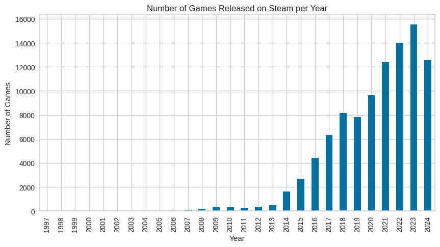

```
Skewness: 1.2566555681031482
```

```python
#Finding number of games released per year ... what is the year with the most games?  what is the most common genre that year?

plt.figure(figsize=(10, 5))

games_per_year = df['release_year'].value_counts().sort_index(ascending=True)
games_per_year.plot(kind='bar', title="Number of Games Released on Steam per Year", xlabel="Year", ylabel="Number of Games")

plt.show()

skewness = games_per_year.skew(axis=0)
print("Skewness:", skewness)
```

**Conclusions**

---- Genres in 2023 (The Most Popular Year for Game Releases) ----

```
The number of games released in 2023 is 15542
```

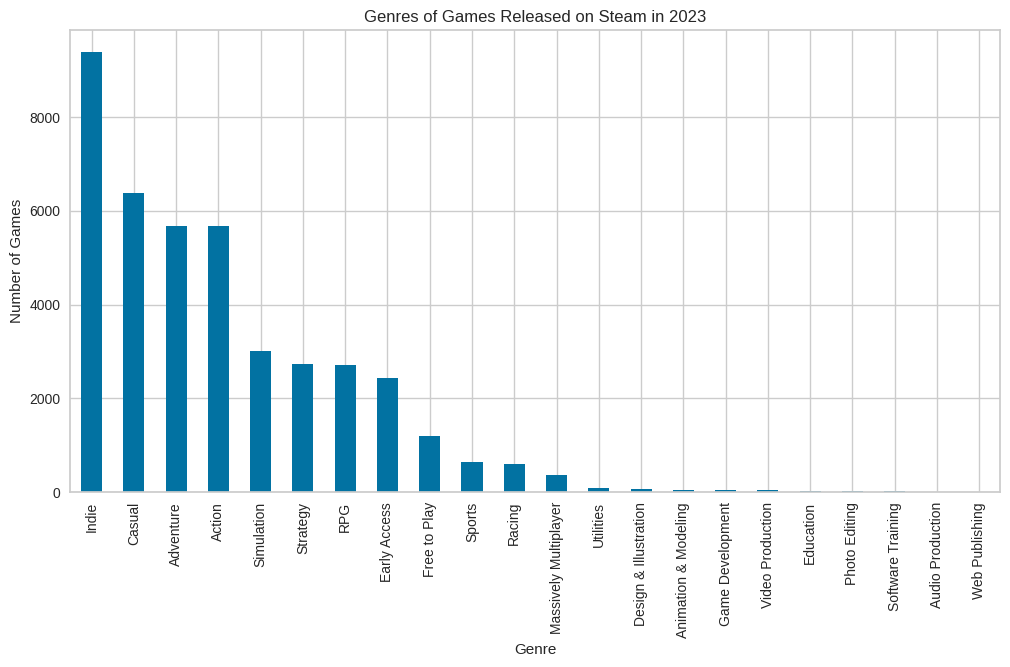

```python
genres_for_2023 = df[df['release_year'] == 2023]["genres"]
genre_count = []

for lst in genres_for_2023:  #combine list of genres for each game into 1 big list
  genre_count.extend(ast.literal_eval(lst))

genre_count = pd.DataFrame(genre_count, columns=["Genre"])
genres_frequencies = genre_count["Genre"].value_counts()

plt.figure(figsize=(12, 6))  # Set figure size
genres_frequencies.plot(kind='bar', title="Genres of Games Released on Steam in 2023", xlabel="Genre", ylabel="Number of Games")

max_year = games_per_year.max()
print("The number of games released in 2023 is", max_year)
```

**Conclusions**

What is the most common genre in 2023?

- The most common genre that year was indie.

---- Most Popular Genre ----

```
     release_year    genres  num_released
0            1997    Action             2
3            1998    Action             1
4            1999    Action             3
6            2000    Action             2
7            2001    Action             3
11           2002    Action             1
13           2003    Action             2
18           2004    Action             7
21           2005       RPG             4
29           2006  Strategy            28
30           2007    Action            66
39           2008    Action            69
49           2009    Action           114
62           2010    Action           122
73           2011    Action           125
84           2012    Action           182
116          2013     Indie           276
136          2014     Indie           918
161          2015     Indie          1934
186          2016     Indie          3095
213          2017     Indie          4480
241          2018     Indie          6220
268          2019     Indie          5922
296          2020     Indie          7144
322          2021     Indie          8186
346          2022     Indie          8729
368          2023     Indie          9380
392          2024     Indie          7744
```

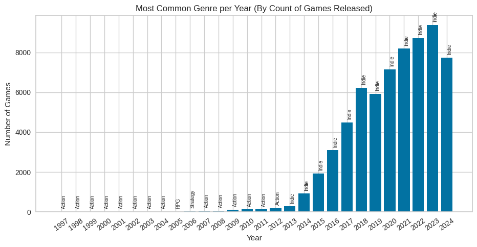

```python
# The most popular genre of games released every year:

# bit of formatting for genres and releast date cols: making genre into list data type instead of string
df['genres'] = df['genres'].map(ast.literal_eval)

df['release_year'] = pd.to_datetime(df['release_dt'], errors='coerce').dt.year
genre_sep = df.explode('genres')
genre_counts = genre_sep.groupby(['release_year', 'genres']).size().reset_index(name='num_released')
most_common_genre_per_year = genre_counts.loc[genre_counts.groupby('release_year')['num_released'].idxmax()]
print(most_common_genre_per_year)
most_common_genre_per_year = most_common_genre_per_year.sort_values('release_year')

plt.figure(figsize=(11, 5))
bars = plt.bar(most_common_genre_per_year['release_year'].astype(str), most_common_genre_per_year['num_released'])

for idx, row in most_common_genre_per_year.iterrows():
    plt.text(
        x=str(row['release_year']),
        y=row['num_released'] + 200,
        s=row['genres'],
        fontsize = 7,
        rotation = 90
    )

plt.title('Most Common Genre per Year (By Count of Games Released)')
plt.xlabel('Year')
plt.ylabel('Number of Games')
plt.xticks(rotation=35)
plt.show()
```

```
genre_combo
['Action', 'Adventure', 'RPG']                                    2459442
['Action', 'Adventure', 'Indie', 'RPG', 'Early Access']           1340591
['Action']                                                        1059314
['Action', 'Free to Play']                                        1028013
['Action', 'Adventure']                                            916442
['Action', 'Free to Play', 'Strategy']                             559661
['Action', 'RPG']                                                  481641
['Action', 'Adventure', 'Indie', 'Simulation', 'Early Access']     416657
['Simulation', 'Sports']                                           399204
['Action', 'Adventure', 'Free to Play']                            307822
Name: peak_ccu, dtype: int64
```

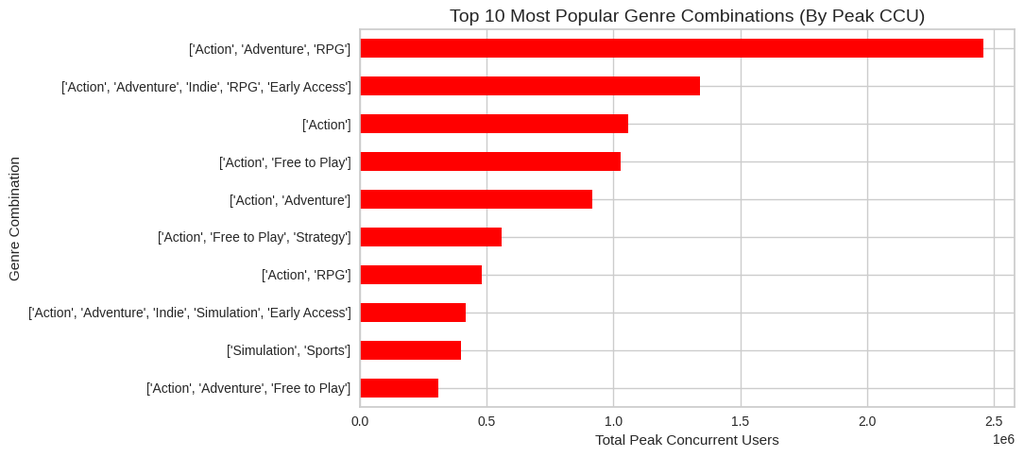

```python
# Top 10 genre combinations that recieved the most peak concurrent players:

df['genre_combo'] = df['genres'].apply(str)
# group by combos (sorted from highest)
combo_popularity = df.groupby('genre_combo')['peak_ccu'].sum().sort_values(ascending=False).head(10)
print(combo_popularity)

plt.figure(figsize=(11, 5))
combo_popularity.sort_values().plot(kind='barh', color='red')
plt.title('Top 10 Most Popular Genre Combinations (By Peak CCU)', fontsize=14)
plt.xlabel('Total Peak Concurrent Users')
plt.ylabel('Genre Combination')
plt.tight_layout()
plt.show()
```

```
     release_year  genres  num_released
0            1997  Action             2
3            1998  Action             1
4            1999  Action             3
6            2000  Action             2
7            2001  Action             3
11           2002  Action             1
13           2003  Action             2
18           2004  Action             7
19           2005  Action             2
23           2006  Action            19
30           2007  Action            66
39           2008  Action            69
49           2009  Action           114
62           2010  Action           122
```

[output cut: 123 more lines]

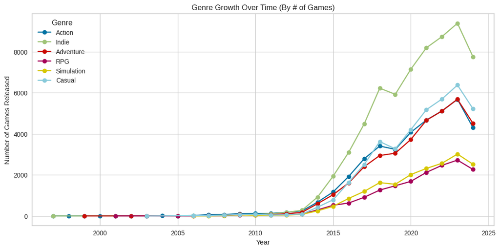

```python
# Genre growth in games over time
select_genres = ['Action', 'Indie', 'Adventure', 'RPG', 'Simulation', 'Casual']
plt.figure(figsize=(13, 6))

for genre in select_genres:
    data = genre_counts[genre_counts['genres'] == genre]
    print(data)
    plt.plot(data['release_year'], data['num_released'], label=genre, marker='o')


plt.title('Genre Growth Over Time (By # of Games)')
plt.xlabel('Year')
plt.ylabel('Number of Games Released')
plt.legend(title='Genre')
plt.show()
```

**Conclusions**

The genre with the most growth overtime is Indie and the genres with the least are Simulation and RPG.

---- Investigating Variable Correlation ----

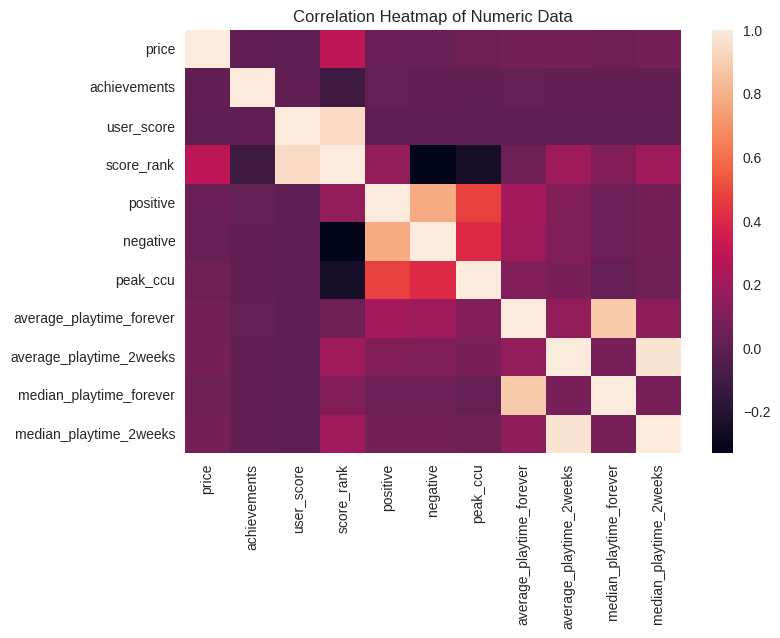

|  |  | 0 |
| --- | --- | --- |
| median_playtime_2weeks | average_playtime_2weeks | 0.972128 |
| average_playtime_2weeks | median_playtime_2weeks | 0.972128 |
| user_score | score_rank | 0.941245 |
| score_rank | user_score | 0.941245 |
| average_playtime_forever | median_playtime_forever | 0.884452 |
| median_playtime_forever | average_playtime_forever | 0.884452 |
| positive | negative | 0.780577 |
| negative | positive | 0.780577 |
| peak_ccu | positive | 0.471492 |

**dtype:** float64

```python
num_df = df[['price', 'achievements', 'user_score', 'score_rank', 'positive', 'negative', 'peak_ccu', 'average_playtime_forever', 'average_playtime_2weeks', 'median_playtime_forever', 'median_playtime_2weeks']].copy()
#creating a new dataframe that only includes the numerical data

matrix = num_df.corr()
sns.heatmap(matrix)
plt.title('Correlation Heatmap of Numeric Data')
plt.show()
#creates a correlation matrix to see if there are any numerical features that correlate, displays matrix as a heatmap

corrs = matrix.abs().unstack().sort_values(ascending=False).head(20)
corrs = corrs[(corrs < 1.0) & (corrs > 0)]
display(corrs)
#displays the highest magnitude correlation coefficients in this correlation matrix, to highlight what potential relationships are present
```

Following these thresholds:

r < 0.25 No relationship

0.25 < r < 0.5 Weak relationship

0.5 < r < 0.75 Moderate relationship

r > 0.75 Strong relationship

**Conclusions:** Among the numeric features, the correlation matrix identified that the following features correlated:

- Median playtime over the last 2 weeks and average playtime over the last 2 weeks had a strong positive relationship (r > 0.75).
- User score and score rank of games had a strong positive relationship (r > 0.75).
- Median playtime forever (since March 2009) and average playtime forever (since March 2009) had a strong positive relationship (r > 0.75).
- Number of positive votes and negative votes had a strong positive relationship (r > 0.75).
- Peak concurrent users (peak CCU) and positve votes had a weak positive relationship (0.25 < r < 0.5).

**Hypothesis**

We hypothesize that the ratio of positive to negative Steam reviews varies significantly across different release years.

**Null Hypothesis (H₀)**

There is no difference in the positive-negative review ratio between release years. (All years have equal review sentiment patterns)

**Alternative Hypothesis (Hₐ)**

There is a significant difference in the positive-negative review ratio between at least some release years. (Some years have more/less favorable reviews than others)

```
ANOVA Results: F-statistic = 60.06, p-value = 0.0000

Significant differences found. Running post-hoc tests...
Multiple Comparison of Means - Tukey HSD, FWER=0.05
====================================================
group1 group2 meandiff p-adj   lower   upper  reject
----------------------------------------------------
  2006   2007    0.727    1.0 -3.4805  4.9345  False
  2006   2008  -2.7125 0.5923 -6.5972  1.1722  False
  2006   2009  -2.7265 0.4359 -6.3351   0.882  False
  2006   2010  -2.4606 0.6535 -6.1022  1.1811  False
  2006   2011  -2.4525 0.6724 -6.1208  1.2158  False
  2006   2012  -2.6438  0.491 -6.2405  0.9529  False
  2006   2013  -2.6855 0.4142 -6.2014  0.8303  False
  2006   2014   -4.019 0.0038 -7.3803 -0.6577   True
```

[output cut: 166 more lines]

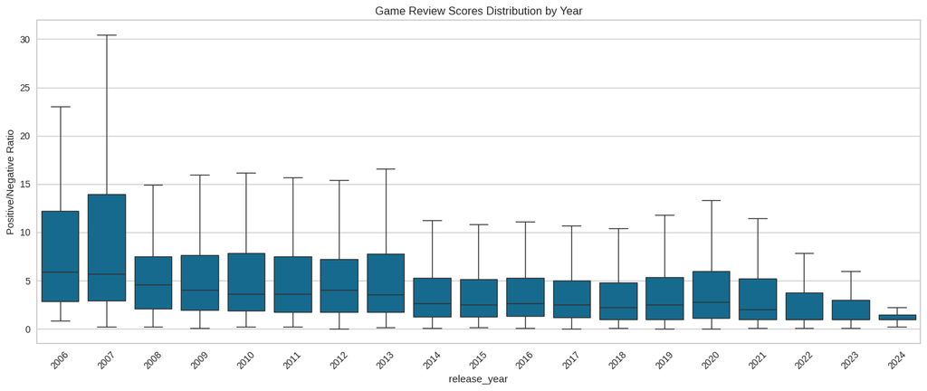

```python
# Calculate review scores safely
df['review_score'] = (pd.to_numeric(df['positive'], errors='coerce') + 1) / \
                     (pd.to_numeric(df['negative'], errors='coerce') + 1)

# Filter valid years and numeric scores
valid_df = df[
    df['release_year'].between(1997, 2024) &
    df['review_score'].notna() &
    np.isfinite(df['review_score'])
]

# Filter years with sufficient data (minimum 30 games)
year_counts = valid_df['release_year'].value_counts()
valid_years = year_counts[year_counts >= 30].index
valid_df = valid_df[valid_df['release_year'].isin(valid_years)]

# One-way ANOVA
groups = [valid_df[valid_df['release_year'] == year]['review_score'] for year in valid_years]
f_stat, p_value = stats.f_oneway(*groups)

print(f"ANOVA Results: F-statistic = {f_stat:.2f}, p-value = {p_value:.4f}")

# Post-hoc test if ANOVA significant
if p_value < 0.05:
    print("\nSignificant differences found. Running post-hoc tests...")

    # Convert years to strings for Tukey test
    valid_df['year_str'] = valid_df['release_year'].astype(str)

    try:
        tukey = pairwise_tukeyhsd(
            endog=valid_df['review_score'],
            groups=valid_df['year_str'],
            alpha=0.05
        )
        print(tukey.summary())

        # Find best year
        yearly_means = valid_df.groupby('release_year')['review_score'].mean()
        best_year = yearly_means.idxmax()
        print(f"\nBest rated year: {best_year} (Mean score: {yearly_means.max():.2f})")

    except Exception as e:
        print(f"Error in Tukey test: {str(e)}")
        print("\nAlternative: Showing yearly mean scores instead")
        print(valid_df.groupby('release_year')['review_score'].mean().sort_values(ascending=False))
else:
    print("\nNo significant differences between years")

# Visualization - Create fresh figure with clean environment
# First reset matplotlib (helps if there were previous conflicts)
import matplotlib
matplotlib.pyplot.close('all')

# Create new figure with explicit pyplot call
fig, ax = plt.subplots(figsize=(14, 6))
sns.boxplot(
    x='release_year',
    y='review_score',
    data=valid_df.sort_values('release_year'),
    showfliers=False,
    ax=ax
)
ax.set_title('Game Review Scores Distribution by Year')
ax.set_xticklabels(ax.get_xticklabels(), rotation=45)
ax.set_ylabel('Positive/Negative Ratio')
plt.tight_layout()
plt.show()
```

**CONCLUSION FROM HYPOTHESIS TEST:**

We can reject the null hypothesis, there is a significant difference in the positive-negative review ratio between at least some release years. (Some years have more/less favorable reviews than others)

---- Investigating Peak CCU ----

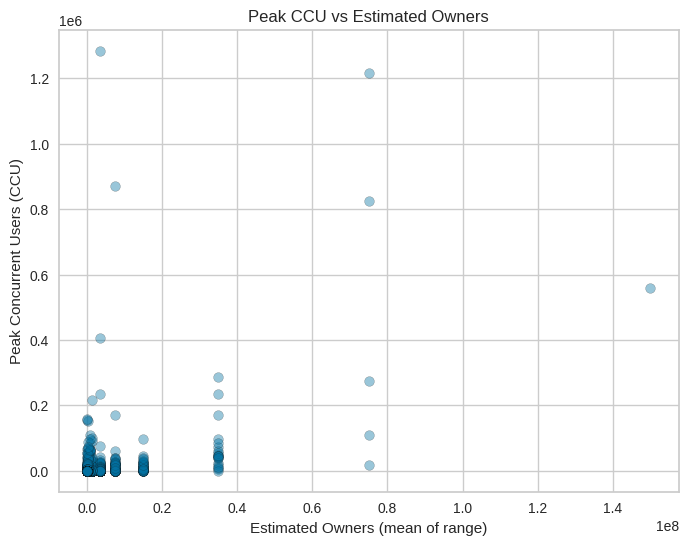

```python
# how are peak CCU and estimated owners related?
plt.figure(figsize=(8,6))
plt.scatter(df['owners_mean'], df['peak_ccu'], alpha=0.4, edgecolors='k')
plt.title("Peak CCU vs Estimated Owners")
plt.xlabel("Estimated Owners (mean of range)")
plt.ylabel("Peak Concurrent Users (CCU)")
plt.grid(True)
plt.show()
```

**Conclusions:** There does not appear to be much correlation between estimated owners and peak CCU.

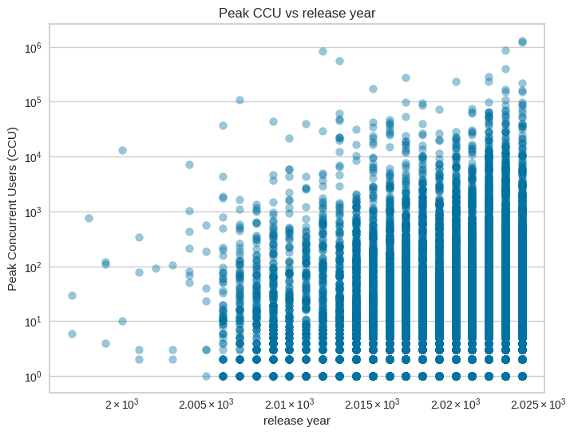

```python
#how are peak ccu and release year related?

plt.figure(figsize=(8,6))
df_try = df[df['peak_ccu'] > 0]
plt.scatter(df_try['release_year'], df_try['peak_ccu'], alpha=0.4)
plt.title("Peak CCU vs release year")
plt.xlabel("release year")
plt.ylabel("Peak Concurrent Users (CCU)")
plt.grid(True)
plt.xscale('log')
plt.yscale('log')
plt.show()
```

**Conclusions:** The max peak CCU appears to have increased over time, which makes sense because the playerbase is growing every year.

**Hypothesis**

We hypothesize that the peak_ccu varies significantly across different release years.

**Null Hypothesis (H₀)**

There is no difference in peak_ccu ratio between release years.

**Alternative Hypothesis (Hₐ)**

There is a significant difference in the peak ccu between at least some release years.

```
ANOVA Results: F-statistic = 3.97, p-value = 0.0000

Significant differences found. Running post-hoc tests...
    Multiple Comparison of Means - Tukey HSD, FWER=0.05
============================================================
group1 group2  meandiff  p-adj    lower      upper    reject
------------------------------------------------------------
  2006   2007   358.4257    1.0 -3800.9099  4517.7614  False
  2006   2008  -638.6933    1.0  -4478.894  3201.5075  False
  2006   2009   -506.631    1.0 -4073.8417  3060.5798  False
  2006   2010   -531.895    1.0 -4131.8236  3068.0335  False
  2006   2011  -482.9472    1.0 -4109.2025  3143.3081  False
  2006   2012  1807.7942 0.9573 -1747.6831  5363.2715  False
  2006   2013  1037.2101 0.9999 -2438.3603  4512.7806  False
  2006   2014  -627.7758    1.0 -3950.6088  2695.0572  False
```

[output cut: 166 more lines]

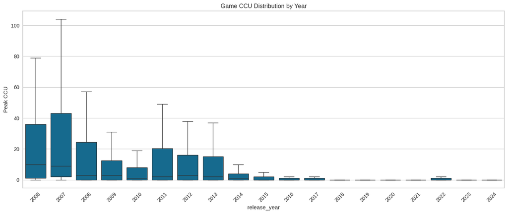

```python
# Calculate review scores safely
df['review_score'] = df['peak_ccu']

# Filter valid years and numeric scores
valid_df = df[
    df['release_year'].between(1997, 2024) &
    df['peak_ccu'].notna() &
    np.isfinite(df['peak_ccu'])
]

# Filter years with sufficient data (minimum 30 games)
year_counts = valid_df['release_year'].value_counts()
valid_years = year_counts[year_counts >= 30].index
valid_df = valid_df[valid_df['release_year'].isin(valid_years)]

# One-way ANOVA
groups = [valid_df[valid_df['release_year'] == year]['peak_ccu'] for year in valid_years]
f_stat, p_value = stats.f_oneway(*groups)

print(f"ANOVA Results: F-statistic = {f_stat:.2f}, p-value = {p_value:.4f}")

# Post-hoc test if ANOVA significant
if p_value < 0.05:
    print("\nSignificant differences found. Running post-hoc tests...")

    # Convert years to strings for Tukey test
    valid_df['year_str'] = valid_df['release_year'].astype(str)

    try:
        tukey = pairwise_tukeyhsd(
            endog=valid_df['peak_ccu'],
            groups=valid_df['year_str'],
            alpha=0.05
        )
        print(tukey.summary())

        # Find best year
        yearly_means = valid_df.groupby('release_year')['peak_ccu'].mean()
        best_year = yearly_means.idxmax()
        print(f"\n Year with Peak CCU: {best_year} (Mean score: {yearly_means.max():.2f})")

    except Exception as e:
        print(f"Error in Tukey test: {str(e)}")
        print("\nAlternative: Showing yearly mean ccus instead")
        print(valid_df.groupby('release_year')['peak_ccu'].mean().sort_values(ascending=False))
else:
    print("\nNo significant differences between years")

# Visualization - Create fresh figure with clean environment
# First reset matplotlib (helps if there were previous conflicts)
import matplotlib
matplotlib.pyplot.close('all')

# Create new figure with explicit pyplot call
fig, ax = plt.subplots(figsize=(14, 6))
sns.boxplot(
    x='release_year',
    y='peak_ccu',
    data=valid_df.sort_values('release_year'),
    showfliers=False,
    ax=ax
)
ax.set_title('Game CCU Distribution by Year')
ax.set_xticklabels(ax.get_xticklabels(), rotation=45)
ax.set_ylabel('Peak CCU')
plt.tight_layout()
plt.show()
```

CONCLUSION FROM HYPOTHESIS TEST: There is a significant difference in average peak CCU between 2012 and other years.

# Primary analysis and visualization.

Based on the results of our exploratory data analysis, we can see that some genres of games are much more popular than others, such as indie, action, and adventure. We can also see from the ANOVA and post hoc test that the positive-to-negative review ratio of some years is significantly different from others, as is the peak CCU. What causes this difference? Is it related to the genres released, or other factors? To answer these questions, we employed two forms of supervised regression machine learning, histogram-based gradient boosting regression tree and random forest, to determine if a game’s peak CCU can be predicted from variables such as price, number of positive reviews, and genre. Regression analysis was chosen because we aim to predict a continuous variable, peak CCU, from many independent variables.

*Please note that since the primary analysis models and visualization of these models are so intertwined, we have combined them into this one section.*

PART 1: REGRESSION TREE. Histogram-based gradient boosting regression tree was chosen because our dataset is very large – 97385 entries. Scikit’s HistGradientBoostingRegressor is designed for big datasets, so it will be better able to handle this regression analysis. Each genre was organized using one-hot encoding so that in the data frame, each column represents a genre, and if a game has a genre, the value in the matrix is 1, and if not, the value is 0. This way, the influence of various combinations of genres can be measured.

```
One‑hot genres shape: (97385, 34)
Final X shape: (97385, 40)
Final y shape: (97385,)
Target distribution: count    97385.000000
mean         0.577619
std          1.386137
min          0.000000
25%          0.000000
50%          0.000000
75%          0.693147
max         14.065700
Name: log_ccu, dtype: float64
Train/Test sizes: 77908 19477

--- Evaluation (log_ccu target) ---
Train MSE: 0.5286374982876964
Train R² : 0.7266198737050164
Test  MSE: 0.5805963858370558
Test  R² : 0.689838287729619

Test R² on raw peak_ccu: 0.158234175252276

Regression Tree Visualization: True Vs Predicted CCU
```

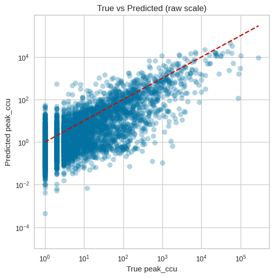

```
Step 10: Computing permutation importances (this may take a moment)…

Top 20 features by permutation importance:
positive                    0.966042
average_playtime_forever    0.173754
average_playtime_2weeks     0.111222
price                       0.099789
negative                    0.043234
Early Access                0.009764
Indie                       0.008377
Strategy                    0.006216
RPG                         0.004785
Action                      0.003610
Simulation                  0.003042
Free to Play                0.002190
Casual                      0.001960
Utilities                   0.001093
Adventure                   0.000934
Animation & Modeling        0.000852
Violent                     0.000245
Racing                      0.000203
Education                   0.000158
Video Production            0.000092
dtype: float64
```

```python
# Step 1: Load & Inspect Missingness
df = pd.read_csv("/content/drive/MyDrive/CMSC320 Group Project/clean_games.csv")

# Step 2: Fill or coerce numeric features (no more drops)
numeric_feats = ['user_score','price','positive','negative',
                'average_playtime_forever','average_playtime_2weeks']
for col in numeric_feats:
    df[col] = pd.to_numeric(df[col], errors='coerce')
df[numeric_feats] = df[numeric_feats].fillna(df[numeric_feats].median())

# Log‐transform target to reduce skew
df['log_ccu'] = np.log1p(df['peak_ccu'])

# Step 3: Parse & one‑hot encode genres
df['genres_list'] = (
    df['genres']
      .str.strip('[]')
      .str.split(',')
      .apply(lambda L: [g.strip(" '\"") for g in L if g.strip()])
)
mlb = MultiLabelBinarizer()
G = pd.DataFrame(mlb.fit_transform(df['genres_list']),
                 columns=mlb.classes_, index=df.index)
print("One‑hot genres shape:", G.shape)

# Step 4: Assemble feature matrix X and target y
X = pd.concat([df[numeric_feats], G], axis=1)
y = df['log_ccu']         # use log target
print("Final X shape:", X.shape)
print("Final y shape:", y.shape)
print("Target distribution:", y.describe())

# Step 5: Train/test split
X_train, X_test, y_train, y_test = train_test_split(
    X, y, test_size=0.2, random_state=42
)
print("Train/Test sizes:", X_train.shape[0], X_test.shape[0])

# Step 6: Scale + train the model
scaler = StandardScaler()
X_train_scaled = scaler.fit_transform(X_train)
X_test_scaled  = scaler.transform(X_test)

model = HistGradientBoostingRegressor(max_iter=200, random_state=42)
model.fit(X_train_scaled, y_train)

# Step 7: Evaluate on log scale
y_train_pred = model.predict(X_train_scaled)
y_test_pred  = model.predict(X_test_scaled)

print("\n--- Evaluation (log_ccu target) ---")
print("Train MSE:", mean_squared_error(y_train, y_train_pred))
print("Train R² :", r2_score(y_train, y_train_pred))
print("Test  MSE:", mean_squared_error(y_test,  y_test_pred))
print("Test  R² :", r2_score(y_test,  y_test_pred))

# Evaluate on original scale
y_test_raw = np.expm1(y_test)
y_pred_raw = np.expm1(y_test_pred)
print("\nTest R² on raw peak_ccu:", r2_score(y_test_raw, y_pred_raw))

# Step 8: Plot True vs Predicted (raw)
print("\nRegression Tree Visualization: True Vs Predicted CCU")
plt.figure(figsize=(6,6))
plt.scatter(y_test_raw, y_pred_raw, alpha=0.3)
plt.xscale('log'); plt.yscale('log')
plt.xlabel('True peak_ccu')
plt.ylabel('Predicted peak_ccu')
plt.title('True vs Predicted (raw scale)')
plt.plot([1, y_test_raw.max()], [1, y_test_raw.max()], 'r--')
plt.grid(True)
plt.show()

# Step 9: Feature importances
from sklearn.inspection import permutation_importance

print("\nStep 10: Computing permutation importances (this may take a moment)…")
perm = permutation_importance(
    model,
    X_test_scaled,
    y_test,
    n_repeats=10,
    random_state=42,
    n_jobs=-1
)

importances = pd.Series(perm.importances_mean, index=X.columns)
importances = importances.sort_values(ascending=False)

print("\nTop 20 features by permutation importance:")
print(importances.head(20))
```

WHAT WE LEARNED: For the regression tree, the R^2 value for testing was 0.69, indicating that 69% of the variance in the dependent variable, peak CCU, was explained by the independent variables (different features). The error for both training and testing were very high (0.53 and 0.58). The top features were the number of positive reviews, average_playtime_forever, and average_playtime_2weeks, and genres all had very low importance, indicating that genre of game is a very weak predictor of peak CCU. While we see a visible positive correlation between the true model and the predicted model in the True Vs Predicted CCU, it could still be improved due to the observed error values. This signaled us to move to other feature designs and machine learning approaches.

```
Best K for Kmeans
\KMeans Visualization 1: Elbow Curve
```

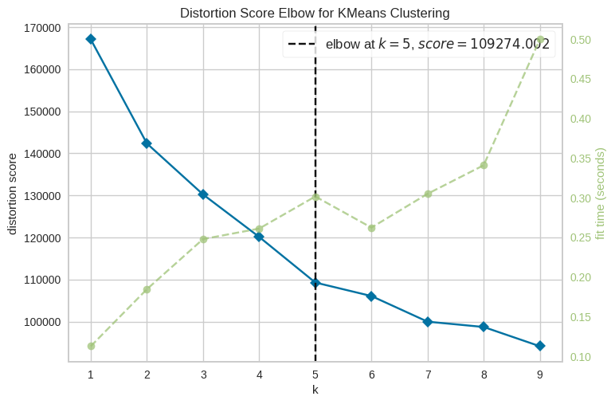

```
Cluster 0 Top Genres
Indie         1.000000
Casual        0.583127
Strategy      0.288082
Simulation    0.278514
RPG           0.134091
Name: 0, dtype: float64

Cluster 1 Top Genres
Casual        0.217075
Action        0.191331
Simulation    0.179611
Strategy      0.168170
RPG           0.102896
Name: 1, dtype: float64

Cluster 2 Top Genres
Casual        1.000000
Action        1.000000
Indie         0.844327
Adventure     0.431395
Simulation    0.209353
Name: 2, dtype: float64

Cluster 3 Top Genres
Action          1.000000
Indie           0.863913
Adventure       0.545738
RPG             0.203556
Early Access    0.183574
Name: 3, dtype: float64

Cluster 4 Top Genres
Adventure     1.000000
Indie         0.823694
Casual        0.510334
RPG           0.287569
Simulation    0.182322
Name: 4, dtype: float64

KMeans Visualization 2: Log CCU by Genre Cluster
```

[figure not shown]

```python
# Trying Kmeans Clustering
model = KMeans(random_state=42, n_init='auto')
# finding ideal k to use for kmeans
print("Best K for Kmeans")
print("\KMeans Visualization 1: Elbow Curve")
visualizer = KElbowVisualizer(model, k=(1, 10))
visualizer.fit(G)
visualizer.show()

k = 5
kmeans = KMeans(n_clusters=k, random_state=42, n_init='auto')
df['genre_clusters'] = kmeans.fit_predict(G)
each_cluster = pd.DataFrame(kmeans.cluster_centers_, columns=mlb.classes_)
each_cluster.index.name = 'Cluster'

# getting top genres from each cluster
for i in range(k):
  top_genres = each_cluster.iloc[i].sort_values(ascending=False).head(5)
  print(f"\nCluster {i} Top Genres")
  print(top_genres)

# plotting clusters
import seaborn as sns
print("\nKMeans Visualization 2: Log CCU by Genre Cluster")
plt.figure(figsize=(8,5))
sns.boxplot(x='genre_clusters', y='log_ccu', data=df)
plt.title("Log CCU by Genre Cluster")
plt.xlabel("Genre Cluster")
plt.ylabel("Positive / (Positive + Negative)")
plt.grid(True)
plt.show()
```

PART 3: RANDOM FOREST. Since the regression tree had high error and genre was found to have low importance, we decided to try modeling peak CCU with a random forest model. Random forest is a good option because the combination of multiple trees to make a decision may increase the accuracy of predictions.

```
<class 'pandas.core.frame.DataFrame'>
RangeIndex: 97385 entries, 0 to 97384
Data columns (total 31 columns):
 #   Column                    Non-Null Count  Dtype
---  ------                    --------------  -----
 0   AppID                     97385 non-null  int64
 1   name                      97379 non-null  object
 2   release_dt                97385 non-null  object
 3   release_date              97385 non-null  object
 4   required_age              97385 non-null  int64
 5   price                     97385 non-null  float64
 6   about_the_game            92515 non-null  object
 7   achievements              97385 non-null  int64
 8   supported_languages       97385 non-null  object
 9   developers                97385 non-null  object
 10  publishers                97385 non-null  object
 11  categories                97385 non-null  object
 12  genres                    97385 non-null  object
 13  user_score                97385 non-null  int64
 14  score_rank                44 non-null     float64
 15  positive                  97385 non-null  int64
 16  negative                  97385 non-null  int64
 17  estimated_owners          97385 non-null  object
 18  average_playtime_forever  97385 non-null  int64
 19  average_playtime_2weeks   97385 non-null  int64
 20  median_playtime_forever   97385 non-null  int64
 21  median_playtime_2weeks    97385 non-null  int64
 22  peak_ccu                  97385 non-null  int64
 23  tags                      97385 non-null  object
 24  release_year              97385 non-null  int64
 25  owners_low                97385 non-null  int64
 26  owners_high               97385 non-null  int64
 27  owners_mean               97385 non-null  float64
 28  log_ccu                   97385 non-null  float64
 29  genres_list               97385 non-null  object
 30  genre_clusters            97385 non-null  int32
dtypes: float64(4), int32(1), int64(14), object(12)
memory usage: 22.7+ MB
  → X shape: (97385, 38)
  → y shape: (97385,) (1-dimensional is correct!)

Random Forest Evaluation:
  • Train MSE: 0.2641  R²: 0.8634
  • Test  MSE: 0.5460  R²: 0.7083

Random Forest Visualization 1: True Vs Predicted CCU
```

[figure not shown]

```
Random Forest Visualization 2: Feature Importances
```

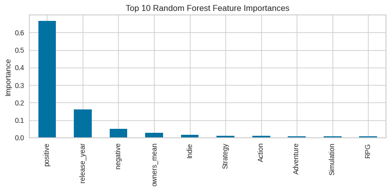

```python
df_rf = df#[df['peak_ccu'] > 2]
df.info()
mlb = MultiLabelBinarizer()
genre_matrix = mlb.fit_transform(df_rf['genres_list'])
X = pd.DataFrame(genre_matrix, columns=mlb.classes_, index=df_rf.index)
X['release_year'] = df_rf['release_year']
X['owners_mean'] = df_rf['owners_mean']
X['positive'] = df_rf['positive']
X['negative'] = df_rf['negative']


y = np.log1p(df_rf['peak_ccu'])
print("  → X shape:", X.shape)
print("  → y shape:", y.shape,  "(1-dimensional is correct!)")

X_train, X_test, y_train, y_test = train_test_split(
    X, y, test_size=0.2, random_state=42
)

# 1. Train Random Forest Regressor
rf_model = RandomForestRegressor(n_estimators=100, max_depth=15, random_state=42)
rf_model.fit(X_train, y_train)

# 2. Predict
y_train_pred_rf = rf_model.predict(X_train)
y_test_pred_rf = rf_model.predict(X_test)

# 3. Evaluate
print("\nRandom Forest Evaluation:")
print("  • Train MSE:", f"{mean_squared_error(y_train, y_train_pred_rf):.4f}",
      " R²:", f"{r2_score(y_train, y_train_pred_rf):.4f}")
print("  • Test  MSE:", f"{mean_squared_error(y_test,  y_test_pred_rf):.4f}",
      " R²:", f"{r2_score(y_test,  y_test_pred_rf):.4f}")

# 4. Plot True vs Predicted
print("\nRandom Forest Visualization 1: True Vs Predicted CCU")
plt.figure(figsize=(6,6))
plt.scatter(y_test, y_test_pred_rf, alpha=0.4)
plt.xlabel("True review_ratio")
plt.ylabel("Predicted review_ratio (Random Forest)")
plt.title("Random Forest: True vs Predicted (Test Set)")
plt.legend()
plt.grid(True)
plt.show()

# 5. Feature Importances
rf_importances = pd.Series(rf_model.feature_importances_, index=X_train.columns)
top_rf_importances = rf_importances.sort_values(ascending=False).head(10)

print("\nRandom Forest Visualization 2: Feature Importances")
plt.figure(figsize=(8,4))
top_rf_importances.plot(kind='bar')
plt.title("Top 10 Random Forest Feature Importances")
plt.ylabel("Importance")
plt.grid(True)
plt.tight_layout()
plt.show()
```

# Insights and Conclusions.

The goal of this project was to investigate what makes a successful video game successful using data from one of the most popular online game marketplaces, Steam. With both the gaming community and gaming industry hosting massive audiences, this investigation was pertinent to many people worldwide. Specifically, we sought to answer the questions:

What genre, popularity, and historical trends are present in the Steam library from 1997-present? Could peak CCU and positive-to-negative rating ratio be predicted using regression? What are the most powerful predictors of measures of positive reception? What were the most common genres present in different clusters of games?

For readers outside of the gaming sphere, our project identifies key trends that would allow them to better understand the demographics of games released on Steam, and how they have changed overtime. For instance, the most popular and fastest-growing genre on Steam is indie games, which are video games developed without support from a large business. This indicates that Steam is an accessible platform that encourages the participation from individuals and small groups for creating and sharing games. In addition, the genre combination with the highest CCU over all time is action, adventure, and RPG. Games with these tags may therefore achieve mainstream popularity with large communities. Overall, these trends give unacquainted readers a better understanding of the history and current preferences of the gaming community on Steam.

For readers who already know about the topic, our project’s primary analysis and visualization provide new insights into what the best predictors of game success are. Using a histogram-based gradient boosting regression tree, we determined that peak CCU can be predicted by user score, price, the number of positive and negative reviews, and playtime with a high error rate. This high error rate indicates that the given statistics are not enough to accurately predict how a game may be received by the gaming community. This conclusion was supported by a followup random forest model, which had a slightly lower but still high error rate. Interestingly, both the histogram gradient boosting regression and the random forest indicated that the strongest predictor of a high CCU was the number of positive reviews, and genres were very low-impact predictors. This insight may be new to readers already familiar with Steam, as the presence of high-ccu action/adventure/RPG games may lead one to assume that when releasing a new game, it has a stronger chance of having a high CCU if it is one of these genres. However, due to the high error rate of the machine learning models and low importance of genre as a feature in predicting CCU, it can be concluded that many complicated factors outside of Steam analytics and game genre contribute to the success of a video game.

With this project, readers new to Steam and those already familiar with it could learn about the trends of the gaming industry over the last 20 years and why a game may or may not be successful. This knowledge would be useful to game development companies, individuals hoping to release indie games on Steam, and members of the gaming community.